# 02. Neural Network Classification with TensorFloe

We've seen how to work a regression problem in TensorFlow, now let's see it's approach in a classification problem.

A `classification problem` involves predicting whether a thing is one or the other. For example:

- Predict whether someone has a heart disease or not, based on their health parameters. `Binary Classification`
- Decide whether a photo is a food, person or dog, with multiple options to pick. `Multi-class Classification`
- Predice what categories chould be assigned to a Wiki article. Where a single article has multiple possible categories to choose. `Multi-label Classification`

We'll be working through a variation of different classification problems.

## What we're going to cover

- Architevture of a classification model
- Input shapes and output shapes
  - `X`: features/data (inputs)
  - `y`: label (outputs)
    - "What class do the inputs belong to?"
  - Creating custom data to view and fit
  - Steps in modelling for binary and multiclass classification
    - Creating a model
    - Compiling a model
      - Defining a loss function
      - Setting up an optimizer
        - Finding the best learning rate
      - Creating evaluation metrics
    - Fitting a model (getting it to find patterns in our data)
    - Improving a model
  - The power of non-linearity
  - Evaluating classification models
    - Visualizing the model ('visualize, visualize, visualize)
    - Looking at training curves
    - Compare predictions to ground truth (using our evluation metrics)

### Typical architecture of a classification neural network

*Typical* is used purposely in this occaison.

Cuz architecture of classification neural network widely vary depending on the problem you're working on.

Though there are fundamentals all deep neural networks contain:

- An input layer
- Some hidden layers
- An output layer

Much of the rest is up to the data analyst creating the model.

The following are some standard values you'll often use in your classification neural networks.

| Hyperparameter | Binary Classification | Multiclass Classification |
| --- | --- | --- |
| Input layer shape | Based on number of features | Same to binary classification |
| Hidden layer(s) | Problem specific, min=1, max=inf | Same to binary classification |
| Neurons per hidden layer | Problem specific, generally 10 to 100 | Same to binary classification |
| Output layer shape | 1 (one class or the other) | 1 per classification variable |
| Hidden activation | Usually ReLU (rectified linear unit) | Same as binary classification |
| Output activation | Sigmoid | Softmax |
| Optimizer | SGD (stochastic gradient descent), Adam | Same to binary classification |

Table above was adapted from a thick ass uni text book ^

Don't worry if most of the content don't make much sense. We'll have plenty of experience as we go through the notebook. We'll start with importing TensorFlow.

```python
import tensorflow as tf
print(tf.__version__)

import datetime
print(f'Notebook last run (end-to-end): {datetime.datetime.now()}')
```

```
2.18.0
Notebook last run (end-to-end): 2025-02-05 23:26:28.489761
```

### Creating data to view and fit

We can start by importing pre-existing classification dataset, but let's practice making our own classification data.

> 💡**Note**: It's common practice to have yourself build, model, and test on a simple dataset, before moving to the big boys. You rehearse yourself on this so called `toy set` before performing on the actual experiment.

As classification is predicting something as one thing or not, let's make a dataset to reflect that.

To do so, we'll use Scikit-Learn's `make_circles()` function.

```python
from sklearn.datasets import make_circles

# Make 1000 examples
n_samples = 1000

# Create circles
X, y = make_circles(n_samples,
                    noise=0.03,
                    random_state=42)
```

Now we've formed data, let's check out `X` and `y`!

```python
# Check out the features
X
```

```
array([[ 0.75424625,  0.23148074],
       [-0.75615888,  0.15325888],
       [-0.81539193,  0.17328203],
       ...,
       [-0.13690036, -0.81001183],
       [ 0.67036156, -0.76750154],
       [ 0.28105665,  0.96382443]])
```

```python
# See the first 10 results of y
y[:10]
```

```
array([1, 1, 1, 1, 0, 1, 1, 1, 1, 0])
```

Let's move into some visualizations

> 💡**Note**: One important step of starting any kind of ML project is `be one with the data`. Best ways to do that is to visualize the data you're working with as much as possible. Again, 'visualize, visualize, visualize'.

We'll start with a DataFrame.

```python
# Make dataframe of features and labels
import pandas as pd
circles = pd.DataFrame({'X0':X[:, 0], 'X1':X[:, 1], 'label':y})
    # X[:, 0] Extracts the first column of X, [0.75424625],  [0.23148074] where we get '0.75424625' instead
    # X[:, 1] Extracts the second column of X, [0.75424625],  [0.23148074] where we get '0.23148074' instead
    # 'label':y adds 'y' values/labels as a column named 'label'
circles.head()
```

|  | X0 | X1 | label |
| --- | --- | --- | --- |
| 0 | 0.754246 | 0.231481 | 1 |
| 1 | -0.756159 | 0.153259 | 1 |
| 2 | -0.815392 | 0.173282 | 1 |
| 3 | -0.393731 | 0.692883 | 1 |
| 4 | 0.442208 | -0.896723 | 0 |

What kind of labels are we dealing with?

```python
# Check out the different labels
circles.label.value_counts()
```

```
label
1    500
0    500
Name: count, dtype: int64
```

Let's have a look at what this **binary classification** problem looks like. Let's take a look at it visually.

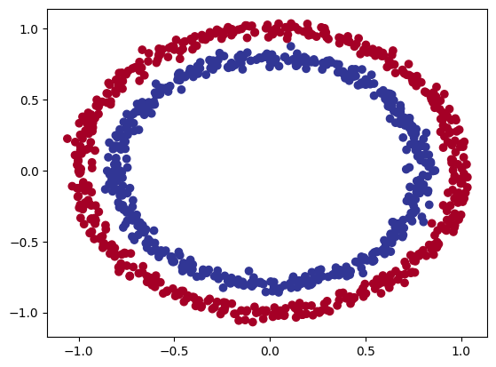

```python
# Visualize with a plot
import matplotlib.pyplot as plt
plt.scatter(X[:, 0], X[:, 1], c=y, cmap=plt.cm.RdYlBu); # c=y > mapping the colour based on the dataset of 'y'
```

We see the difference between the two is based on the size of the circles! Let's try a build a model that can distinguish these blue and red dots, aka identifying which is part of the small circle, or the big circle.

> 📝Practice: Before continuing, it might be worthwhile to spend about 10 minutes playing around with `TensorFlow Playground`. Try adjusting hyperparamers, click and see neural network train.

### Input and output shapes

One of the most common issues you'll run into when building neural networks is shape mismatches. Aka the input and output shapes are not as what was expected, similar to what we've talked about in workbook 01.

Here, we want to input `X` and output `y`.

So let's check both their shapes.

```python
# Check shapes of X and y
X.shape, y.shape
```

```
((1000, 2), (1000,))
```

```python
# Check length
len(X), len(y)
```

```
(1000, 1000)
```

We got the same amount of `X` and `y`, which should always be the case. If not, then we need to do a bit of investigating and clean some data.

Let's check first example

```python
# Check first example
X[0], y[1]
```

```
(array([0.75424625, 0.23148074]), np.int64(1))
```

So now we've got two `X` Features, which leads to one `y` value.

For our neural network, this means accepting a one dimensional array that has 2 values, then outputting a singular value.

> 💡**Note**: `y` having (1000,) looks weird, but it's cuz `y` values are scalar (single values), therefore it doesn't have dimension. So think of it as the same as 1d, 2d, and 3d arrays. But minus 1 to the number of dimensions to get what we have.

### Steps in modelling

Now we know what data we have, as well as input and output shapews. Let's see how we can build a neural network model to it.

In TensorFlow, there are typically 3 fundamental steps to creating and training a model.

1. **Creating a model** - piece together layer of a neural network yourself (using functional or sequential API) or import previously built models (transfer learning).
2. **Compiling a model** - defining how a model's performance should be measured (loss/metrics), and defining how it should improve (optimizer).
3. **Fitting a model** - letting the model try to find patterns in the data.

Let's see this in action with Sequential API to build a model for our regression data. We'll step through each one by one.

```python
# Set random seed
tf.random.set_seed(42)

# 1. Create the model using the Sequential API
model_1 = tf.keras.Sequential([
    tf.keras.layers.Dense(1)
])

# 2. Compile the model
model_1.compile(loss=tf.keras.losses.BinaryCrossentropy(), # binary since we are working with 2 classes (0 & 1)
                optimizer=tf.keras.optimizers.SGD(),
                metrics=['accuracy'])

# 3. Fit the model
model_1.fit(X, y, epochs=5)
```

```
32/32 ━━━━━━━━━━━━━━━━━━━━ 1s 3ms/step - accuracy: 0.4290 - loss: 3.8751
32/32 ━━━━━━━━━━━━━━━━━━━━ 0s 3ms/step - accuracy: 0.4692 - loss: 0.7836
32/32 ━━━━━━━━━━━━━━━━━━━━ 0s 3ms/step - accuracy: 0.4692 - loss: 0.7254
32/32 ━━━━━━━━━━━━━━━━━━━━ 0s 3ms/step - accuracy: 0.4705 - loss: 0.7078
32/32 ━━━━━━━━━━━━━━━━━━━━ 0s 3ms/step - accuracy: 0.4713 - loss: 0.7010
```

```
<keras.src.callbacks.history.History at 0x2ae20fad760>
```

Looking at the results, it's not ideal as only 46% was classified correctly, practically equivalent to guessing. Let's train it for longer

```python
# train our model for longer
model_1.fit(X, y, epochs=200, verbose=1)
model_1.evaluate(X, y)
```

```
32/32 ━━━━━━━━━━━━━━━━━━━━ 0s 3ms/step - accuracy: 0.4633 - loss: 0.6979
32/32 ━━━━━━━━━━━━━━━━━━━━ 0s 4ms/step - accuracy: 0.4621 - loss: 0.6965
32/32 ━━━━━━━━━━━━━━━━━━━━ 0s 3ms/step - accuracy: 0.4472 - loss: 0.6958
32/32 ━━━━━━━━━━━━━━━━━━━━ 0s 4ms/step - accuracy: 0.4337 - loss: 0.6954
32/32 ━━━━━━━━━━━━━━━━━━━━ 0s 4ms/step - accuracy: 0.4391 - loss: 0.6951
32/32 ━━━━━━━━━━━━━━━━━━━━ 0s 3ms/step - accuracy: 0.4472 - loss: 0.6950
32/32 ━━━━━━━━━━━━━━━━━━━━ 0s 3ms/step - accuracy: 0.4440 - loss: 0.6949
32/32 ━━━━━━━━━━━━━━━━━━━━ 0s 3ms/step - accuracy: 0.4405 - loss: 0.6949
32/32 ━━━━━━━━━━━━━━━━━━━━ 0s 3ms/step - accuracy: 0.4370 - loss: 0.6949
32/32 ━━━━━━━━━━━━━━━━━━━━ 0s 3ms/step - accuracy: 0.4322 - loss: 0.6949
32/32 ━━━━━━━━━━━━━━━━━━━━ 0s 3ms/step - accuracy: 0.4314 - loss: 0.6949
32/32 ━━━━━━━━━━━━━━━━━━━━ 0s 3ms/step - accuracy: 0.4299 - loss: 0.6949
32/32 ━━━━━━━━━━━━━━━━━━━━ 0s 3ms/step - accuracy: 0.4274 - loss: 0.6949
32/32 ━━━━━━━━━━━━━━━━━━━━ 0s 4ms/step - accuracy: 0.4281 - loss: 0.6949
32/32 ━━━━━━━━━━━━━━━━━━━━ 0s 4ms/step - accuracy: 0.4281 - loss: 0.6948
32/32 ━━━━━━━━━━━━━━━━━━━━ 0s 3ms/step - accuracy: 0.4281 - loss: 0.6948
32/32 ━━━━━━━━━━━━━━━━━━━━ 0s 3ms/step - accuracy: 0.4281 - loss: 0.6948
32/32 ━━━━━━━━━━━━━━━━━━━━ 0s 3ms/step - accuracy: 0.4281 - loss: 0.6948
32/32 ━━━━━━━━━━━━━━━━━━━━ 0s 3ms/step - accuracy: 0.4281 - loss: 0.6948
32/32 ━━━━━━━━━━━━━━━━━━━━ 0s 3ms/step - accuracy: 0.4274 - loss: 0.6948
32/32 ━━━━━━━━━━━━━━━━━━━━ 0s 3ms/step - accuracy: 0.4274 - loss: 0.6948
32/32 ━━━━━━━━━━━━━━━━━━━━ 0s 3ms/step - accuracy: 0.4274 - loss: 0.6948
32/32 ━━━━━━━━━━━━━━━━━━━━ 0s 3ms/step - accuracy: 0.4274 - loss: 0.6948
32/32 ━━━━━━━━━━━━━━━━━━━━ 0s 3ms/step - accuracy: 0.4271 - loss: 0.6948
32/32 ━━━━━━━━━━━━━━━━━━━━ 0s 3ms/step - accuracy: 0.4271 - loss: 0.6948
32/32 ━━━━━━━━━━━━━━━━━━━━ 0s 3ms/step - accuracy: 0.4271 - loss: 0.6948
32/32 ━━━━━━━━━━━━━━━━━━━━ 0s 4ms/step - accuracy: 0.4271 - loss: 0.6948
32/32 ━━━━━━━━━━━━━━━━━━━━ 0s 4ms/step - accuracy: 0.4271 - loss: 0.6948
32/32 ━━━━━━━━━━━━━━━━━━━━ 0s 3ms/step - accuracy: 0.4271 - loss: 0.6948
32/32 ━━━━━━━━━━━━━━━━━━━━ 0s 3ms/step - accuracy: 0.4271 - loss: 0.6948
32/32 ━━━━━━━━━━━━━━━━━━━━ 0s 3ms/step - accuracy: 0.4271 - loss: 0.6948
32/32 ━━━━━━━━━━━━━━━━━━━━ 0s 3ms/step - accuracy: 0.4271 - loss: 0.6948
32/32 ━━━━━━━━━━━━━━━━━━━━ 0s 3ms/step - accuracy: 0.4271 - loss: 0.6948
32/32 ━━━━━━━━━━━━━━━━━━━━ 0s 3ms/step - accuracy: 0.4271 - loss: 0.6948
32/32 ━━━━━━━━━━━━━━━━━━━━ 0s 4ms/step - accuracy: 0.4271 - loss: 0.6948
32/32 ━━━━━━━━━━━━━━━━━━━━ 0s 3ms/step - accuracy: 0.4271 - loss: 0.6948
32/32 ━━━━━━━━━━━━━━━━━━━━ 0s 3ms/step - accuracy: 0.4271 - loss: 0.6948
32/32 ━━━━━━━━━━━━━━━━━━━━ 0s 4ms/step - accuracy: 0.4271 - loss: 0.6948
32/32 ━━━━━━━━━━━━━━━━━━━━ 0s 4ms/step - accuracy: 0.4271 - loss: 0.6948
32/32 ━━━━━━━━━━━━━━━━━━━━ 0s 4ms/step - accuracy: 0.4271 - loss: 0.6948
```

[output cut: 146 more lines]

```
32/32 ━━━━━━━━━━━━━━━━━━━━ 0s 3ms/step - accuracy: 0.4271 - loss: 0.6948
32/32 ━━━━━━━━━━━━━━━━━━━━ 0s 3ms/step - accuracy: 0.4271 - loss: 0.6948
32/32 ━━━━━━━━━━━━━━━━━━━━ 0s 4ms/step - accuracy: 0.4271 - loss: 0.6948
32/32 ━━━━━━━━━━━━━━━━━━━━ 0s 4ms/step - accuracy: 0.4271 - loss: 0.6948
32/32 ━━━━━━━━━━━━━━━━━━━━ 0s 3ms/step - accuracy: 0.4271 - loss: 0.6948
32/32 ━━━━━━━━━━━━━━━━━━━━ 0s 4ms/step - accuracy: 0.4271 - loss: 0.6948
32/32 ━━━━━━━━━━━━━━━━━━━━ 0s 4ms/step - accuracy: 0.4271 - loss: 0.6948
32/32 ━━━━━━━━━━━━━━━━━━━━ 0s 5ms/step - accuracy: 0.4271 - loss: 0.6948
32/32 ━━━━━━━━━━━━━━━━━━━━ 0s 3ms/step - accuracy: 0.4271 - loss: 0.6948
32/32 ━━━━━━━━━━━━━━━━━━━━ 0s 3ms/step - accuracy: 0.4271 - loss: 0.6948
32/32 ━━━━━━━━━━━━━━━━━━━━ 0s 5ms/step - accuracy: 0.4271 - loss: 0.6948
32/32 ━━━━━━━━━━━━━━━━━━━━ 0s 3ms/step - accuracy: 0.4271 - loss: 0.6948
32/32 ━━━━━━━━━━━━━━━━━━━━ 0s 3ms/step - accuracy: 0.4271 - loss: 0.6948
32/32 ━━━━━━━━━━━━━━━━━━━━ 0s 3ms/step - accuracy: 0.4271 - loss: 0.6948
32/32 ━━━━━━━━━━━━━━━━━━━━ 0s 3ms/step - accuracy: 0.4852 - loss: 0.6927
```

```
[0.6932879686355591, 0.4729999899864197]
```

Results are absolutely appaling. After a while, the model just gave up, and returned the same results over and over. Literally no improvement made.

Let's add another layer in the model, and epochs = 100?

```python
# Set random seed
tf.random.set_seed(42)

# 1. Create the model using the Sequential API
model_1 = tf.keras.Sequential([
    tf.keras.layers.Dense(1),
    tf.keras.layers.Dense(1)
])

# 2. Compile the model
model_1.compile(loss=tf.keras.losses.BinaryCrossentropy(), # binary since we are working with 2 classes (0 & 1)
                optimizer=tf.keras.optimizers.SGD(),
                metrics=['accuracy'])

# 3. Fit the model
model_1.fit(X, y, epochs=100)
```

```
32/32 ━━━━━━━━━━━━━━━━━━━━ 1s 3ms/step - accuracy: 0.4487 - loss: 1.8518
32/32 ━━━━━━━━━━━━━━━━━━━━ 0s 3ms/step - accuracy: 0.4249 - loss: 0.7044
32/32 ━━━━━━━━━━━━━━━━━━━━ 0s 4ms/step - accuracy: 0.4603 - loss: 0.6962
32/32 ━━━━━━━━━━━━━━━━━━━━ 0s 4ms/step - accuracy: 0.4296 - loss: 0.6951
32/32 ━━━━━━━━━━━━━━━━━━━━ 0s 5ms/step - accuracy: 0.4463 - loss: 0.6948
32/32 ━━━━━━━━━━━━━━━━━━━━ 0s 3ms/step - accuracy: 0.4406 - loss: 0.6948
32/32 ━━━━━━━━━━━━━━━━━━━━ 0s 3ms/step - accuracy: 0.4363 - loss: 0.6948
32/32 ━━━━━━━━━━━━━━━━━━━━ 0s 3ms/step - accuracy: 0.4390 - loss: 0.6948
32/32 ━━━━━━━━━━━━━━━━━━━━ 0s 3ms/step - accuracy: 0.4390 - loss: 0.6948
32/32 ━━━━━━━━━━━━━━━━━━━━ 0s 4ms/step - accuracy: 0.4390 - loss: 0.6948
32/32 ━━━━━━━━━━━━━━━━━━━━ 0s 3ms/step - accuracy: 0.4390 - loss: 0.6948
32/32 ━━━━━━━━━━━━━━━━━━━━ 0s 4ms/step - accuracy: 0.4390 - loss: 0.6948
32/32 ━━━━━━━━━━━━━━━━━━━━ 0s 3ms/step - accuracy: 0.4390 - loss: 0.6948
32/32 ━━━━━━━━━━━━━━━━━━━━ 0s 4ms/step - accuracy: 0.4390 - loss: 0.6948
32/32 ━━━━━━━━━━━━━━━━━━━━ 0s 4ms/step - accuracy: 0.4390 - loss: 0.6948
32/32 ━━━━━━━━━━━━━━━━━━━━ 0s 5ms/step - accuracy: 0.4390 - loss: 0.6948
32/32 ━━━━━━━━━━━━━━━━━━━━ 0s 3ms/step - accuracy: 0.4390 - loss: 0.6948
32/32 ━━━━━━━━━━━━━━━━━━━━ 0s 3ms/step - accuracy: 0.4390 - loss: 0.6947
32/32 ━━━━━━━━━━━━━━━━━━━━ 0s 3ms/step - accuracy: 0.4390 - loss: 0.6947
32/32 ━━━━━━━━━━━━━━━━━━━━ 0s 3ms/step - accuracy: 0.4390 - loss: 0.6947
32/32 ━━━━━━━━━━━━━━━━━━━━ 0s 3ms/step - accuracy: 0.4390 - loss: 0.6947
32/32 ━━━━━━━━━━━━━━━━━━━━ 0s 3ms/step - accuracy: 0.4390 - loss: 0.6947
32/32 ━━━━━━━━━━━━━━━━━━━━ 0s 3ms/step - accuracy: 0.4374 - loss: 0.6947
32/32 ━━━━━━━━━━━━━━━━━━━━ 0s 4ms/step - accuracy: 0.4374 - loss: 0.6947
32/32 ━━━━━━━━━━━━━━━━━━━━ 0s 3ms/step - accuracy: 0.4374 - loss: 0.6947
32/32 ━━━━━━━━━━━━━━━━━━━━ 0s 5ms/step - accuracy: 0.4374 - loss: 0.6947
32/32 ━━━━━━━━━━━━━━━━━━━━ 0s 4ms/step - accuracy: 0.4374 - loss: 0.6947
32/32 ━━━━━━━━━━━━━━━━━━━━ 0s 4ms/step - accuracy: 0.4374 - loss: 0.6947
32/32 ━━━━━━━━━━━━━━━━━━━━ 0s 4ms/step - accuracy: 0.4374 - loss: 0.6947
32/32 ━━━━━━━━━━━━━━━━━━━━ 0s 4ms/step - accuracy: 0.4374 - loss: 0.6947
32/32 ━━━━━━━━━━━━━━━━━━━━ 0s 3ms/step - accuracy: 0.4374 - loss: 0.6947
32/32 ━━━━━━━━━━━━━━━━━━━━ 0s 4ms/step - accuracy: 0.4374 - loss: 0.6947
32/32 ━━━━━━━━━━━━━━━━━━━━ 0s 5ms/step - accuracy: 0.4374 - loss: 0.6947
32/32 ━━━━━━━━━━━━━━━━━━━━ 0s 4ms/step - accuracy: 0.4374 - loss: 0.6947
32/32 ━━━━━━━━━━━━━━━━━━━━ 0s 4ms/step - accuracy: 0.4374 - loss: 0.6947
32/32 ━━━━━━━━━━━━━━━━━━━━ 0s 3ms/step - accuracy: 0.4374 - loss: 0.6947
32/32 ━━━━━━━━━━━━━━━━━━━━ 0s 3ms/step - accuracy: 0.4374 - loss: 0.6947
32/32 ━━━━━━━━━━━━━━━━━━━━ 0s 3ms/step - accuracy: 0.4374 - loss: 0.6947
32/32 ━━━━━━━━━━━━━━━━━━━━ 0s 3ms/step - accuracy: 0.4374 - loss: 0.6947
32/32 ━━━━━━━━━━━━━━━━━━━━ 0s 4ms/step - accuracy: 0.4374 - loss: 0.6947
```

[output cut: 45 more lines]

```
32/32 ━━━━━━━━━━━━━━━━━━━━ 0s 4ms/step - accuracy: 0.4292 - loss: 0.6947
32/32 ━━━━━━━━━━━━━━━━━━━━ 0s 5ms/step - accuracy: 0.4292 - loss: 0.6947
32/32 ━━━━━━━━━━━━━━━━━━━━ 0s 6ms/step - accuracy: 0.4292 - loss: 0.6947
32/32 ━━━━━━━━━━━━━━━━━━━━ 0s 4ms/step - accuracy: 0.4292 - loss: 0.6947
32/32 ━━━━━━━━━━━━━━━━━━━━ 0s 3ms/step - accuracy: 0.4292 - loss: 0.6947
32/32 ━━━━━━━━━━━━━━━━━━━━ 0s 4ms/step - accuracy: 0.4296 - loss: 0.6947
32/32 ━━━━━━━━━━━━━━━━━━━━ 0s 3ms/step - accuracy: 0.4296 - loss: 0.6947
32/32 ━━━━━━━━━━━━━━━━━━━━ 0s 3ms/step - accuracy: 0.4296 - loss: 0.6947
32/32 ━━━━━━━━━━━━━━━━━━━━ 0s 3ms/step - accuracy: 0.4296 - loss: 0.6947
32/32 ━━━━━━━━━━━━━━━━━━━━ 0s 3ms/step - accuracy: 0.4296 - loss: 0.6947
32/32 ━━━━━━━━━━━━━━━━━━━━ 0s 3ms/step - accuracy: 0.4296 - loss: 0.6947
32/32 ━━━━━━━━━━━━━━━━━━━━ 0s 4ms/step - accuracy: 0.4296 - loss: 0.6947
32/32 ━━━━━━━━━━━━━━━━━━━━ 0s 4ms/step - accuracy: 0.4296 - loss: 0.6947
32/32 ━━━━━━━━━━━━━━━━━━━━ 0s 3ms/step - accuracy: 0.4296 - loss: 0.6947
32/32 ━━━━━━━━━━━━━━━━━━━━ 0s 3ms/step - accuracy: 0.4296 - loss: 0.6947
```

```
<keras.src.callbacks.history.History at 0x2ae2588c910>
```

No improvement at all. Let's firstly remind ourselves what more ways we can use to improve our model's accuracy.

### Improving a model

To improve our model, we can alter almost every part of the 3 steps we went through before.

1. **Creating a model** - piece together layer of a neural network yourself (using functional or sequential API) or import previously built models (transfer learning).
2. **Compiling a model** - defining how a model's performance should be measured (loss/metrics), and defining how it should improve (optimizer).
3. **Fitting a model** - letting the model try to find patterns in the data.

[figure not shown]

Remember this image from the previous workbook? These would help us when we're in a pickle... mostly.

For our rehearsing, let's try adding more neurons, another layer, and use the `Adam` optimizer.

```python
tf.random.set_seed(42)

model_3 = tf.keras.Sequential([
    tf.keras.layers.Dense(100),
    tf.keras.layers.Dense(10),
    tf.keras.layers.Dense(1)
])

model_3.compile(loss=tf.keras.losses.BinaryCrossentropy(),
                optimizer=tf.keras.optimizers.Adam(), # use Adam over SGD
                metrics=['accuracy'])

model_3.fit(X, y, epochs=100, verbose=1)
```

```
32/32 ━━━━━━━━━━━━━━━━━━━━ 2s 5ms/step - accuracy: 0.4527 - loss: 3.5912
32/32 ━━━━━━━━━━━━━━━━━━━━ 0s 4ms/step - accuracy: 0.4447 - loss: 0.7524
32/32 ━━━━━━━━━━━━━━━━━━━━ 0s 4ms/step - accuracy: 0.4237 - loss: 0.7051
32/32 ━━━━━━━━━━━━━━━━━━━━ 0s 5ms/step - accuracy: 0.4394 - loss: 0.6947
32/32 ━━━━━━━━━━━━━━━━━━━━ 0s 4ms/step - accuracy: 0.4481 - loss: 0.6953
32/32 ━━━━━━━━━━━━━━━━━━━━ 0s 4ms/step - accuracy: 0.4514 - loss: 0.6956
32/32 ━━━━━━━━━━━━━━━━━━━━ 0s 3ms/step - accuracy: 0.4513 - loss: 0.6959
32/32 ━━━━━━━━━━━━━━━━━━━━ 0s 4ms/step - accuracy: 0.4516 - loss: 0.6961
32/32 ━━━━━━━━━━━━━━━━━━━━ 0s 3ms/step - accuracy: 0.4541 - loss: 0.6964
32/32 ━━━━━━━━━━━━━━━━━━━━ 0s 4ms/step - accuracy: 0.4559 - loss: 0.6966
32/32 ━━━━━━━━━━━━━━━━━━━━ 0s 3ms/step - accuracy: 0.4550 - loss: 0.6968
32/32 ━━━━━━━━━━━━━━━━━━━━ 0s 4ms/step - accuracy: 0.4557 - loss: 0.6970
32/32 ━━━━━━━━━━━━━━━━━━━━ 0s 3ms/step - accuracy: 0.4571 - loss: 0.6972
32/32 ━━━━━━━━━━━━━━━━━━━━ 0s 5ms/step - accuracy: 0.4604 - loss: 0.6974
32/32 ━━━━━━━━━━━━━━━━━━━━ 0s 8ms/step - accuracy: 0.4605 - loss: 0.6976
32/32 ━━━━━━━━━━━━━━━━━━━━ 0s 5ms/step - accuracy: 0.4580 - loss: 0.6978
32/32 ━━━━━━━━━━━━━━━━━━━━ 0s 5ms/step - accuracy: 0.4584 - loss: 0.6979
32/32 ━━━━━━━━━━━━━━━━━━━━ 0s 4ms/step - accuracy: 0.4604 - loss: 0.6981
32/32 ━━━━━━━━━━━━━━━━━━━━ 0s 5ms/step - accuracy: 0.4596 - loss: 0.6983
32/32 ━━━━━━━━━━━━━━━━━━━━ 0s 4ms/step - accuracy: 0.4602 - loss: 0.6984
32/32 ━━━━━━━━━━━━━━━━━━━━ 0s 5ms/step - accuracy: 0.4617 - loss: 0.6986
32/32 ━━━━━━━━━━━━━━━━━━━━ 0s 11ms/step - accuracy: 0.4617 - loss: 0.6987
32/32 ━━━━━━━━━━━━━━━━━━━━ 0s 7ms/step - accuracy: 0.4611 - loss: 0.6989
32/32 ━━━━━━━━━━━━━━━━━━━━ 0s 3ms/step - accuracy: 0.4615 - loss: 0.6990
32/32 ━━━━━━━━━━━━━━━━━━━━ 0s 3ms/step - accuracy: 0.4609 - loss: 0.6992
32/32 ━━━━━━━━━━━━━━━━━━━━ 0s 3ms/step - accuracy: 0.4614 - loss: 0.6993
32/32 ━━━━━━━━━━━━━━━━━━━━ 0s 3ms/step - accuracy: 0.4597 - loss: 0.6994
32/32 ━━━━━━━━━━━━━━━━━━━━ 0s 3ms/step - accuracy: 0.4574 - loss: 0.6996
32/32 ━━━━━━━━━━━━━━━━━━━━ 0s 3ms/step - accuracy: 0.4574 - loss: 0.6997
32/32 ━━━━━━━━━━━━━━━━━━━━ 0s 3ms/step - accuracy: 0.4561 - loss: 0.6998
32/32 ━━━━━━━━━━━━━━━━━━━━ 0s 3ms/step - accuracy: 0.4545 - loss: 0.6999
32/32 ━━━━━━━━━━━━━━━━━━━━ 0s 4ms/step - accuracy: 0.4579 - loss: 0.7000
32/32 ━━━━━━━━━━━━━━━━━━━━ 0s 5ms/step - accuracy: 0.4530 - loss: 0.7001
32/32 ━━━━━━━━━━━━━━━━━━━━ 0s 5ms/step - accuracy: 0.4511 - loss: 0.7002
32/32 ━━━━━━━━━━━━━━━━━━━━ 0s 3ms/step - accuracy: 0.4521 - loss: 0.7003
32/32 ━━━━━━━━━━━━━━━━━━━━ 0s 3ms/step - accuracy: 0.4463 - loss: 0.7004
32/32 ━━━━━━━━━━━━━━━━━━━━ 0s 3ms/step - accuracy: 0.4460 - loss: 0.7005
32/32 ━━━━━━━━━━━━━━━━━━━━ 0s 3ms/step - accuracy: 0.4464 - loss: 0.7006
32/32 ━━━━━━━━━━━━━━━━━━━━ 0s 3ms/step - accuracy: 0.4467 - loss: 0.7007
32/32 ━━━━━━━━━━━━━━━━━━━━ 0s 3ms/step - accuracy: 0.4486 - loss: 0.7008
```

[output cut: 45 more lines]

```
32/32 ━━━━━━━━━━━━━━━━━━━━ 0s 3ms/step - accuracy: 0.4498 - loss: 0.7016
32/32 ━━━━━━━━━━━━━━━━━━━━ 0s 4ms/step - accuracy: 0.4514 - loss: 0.7016
32/32 ━━━━━━━━━━━━━━━━━━━━ 0s 4ms/step - accuracy: 0.4517 - loss: 0.7016
32/32 ━━━━━━━━━━━━━━━━━━━━ 0s 3ms/step - accuracy: 0.4517 - loss: 0.7015
32/32 ━━━━━━━━━━━━━━━━━━━━ 0s 3ms/step - accuracy: 0.4517 - loss: 0.7015
32/32 ━━━━━━━━━━━━━━━━━━━━ 0s 4ms/step - accuracy: 0.4519 - loss: 0.7015
32/32 ━━━━━━━━━━━━━━━━━━━━ 0s 3ms/step - accuracy: 0.4512 - loss: 0.7015
32/32 ━━━━━━━━━━━━━━━━━━━━ 0s 3ms/step - accuracy: 0.4512 - loss: 0.7014
32/32 ━━━━━━━━━━━━━━━━━━━━ 0s 3ms/step - accuracy: 0.4512 - loss: 0.7014
32/32 ━━━━━━━━━━━━━━━━━━━━ 0s 3ms/step - accuracy: 0.4497 - loss: 0.7014
32/32 ━━━━━━━━━━━━━━━━━━━━ 0s 3ms/step - accuracy: 0.4494 - loss: 0.7013
32/32 ━━━━━━━━━━━━━━━━━━━━ 0s 3ms/step - accuracy: 0.4499 - loss: 0.7013
32/32 ━━━━━━━━━━━━━━━━━━━━ 0s 3ms/step - accuracy: 0.4499 - loss: 0.7013
32/32 ━━━━━━━━━━━━━━━━━━━━ 0s 4ms/step - accuracy: 0.4499 - loss: 0.7013
32/32 ━━━━━━━━━━━━━━━━━━━━ 0s 4ms/step - accuracy: 0.4499 - loss: 0.7012
```

```
<keras.src.callbacks.history.History at 0x2ae259b5e20>
```

Despite some fancy tricks up our pants, nothing!

Let's visualize and see what is happening.

> 💡**Note**: Whenever your model performs strangely, or you don't know what's happening with your data, always remember to visualize. Inspect the data, the model, and it's predictions.

To visualize our model's predictions we're going to create a function `plot_decision_boundary()` which:

- Takes in a trained model, features (`X`) and labels (`y`).
- Creates a `meshgrid` of the different `X` values.
- Makes predictions across the meshgrid.
- Plots the predictions as well as a line between the different zones (where each unique class falls).

If this sounds confusing, let's see it in code and it's output.

> 💡**Note**: If you're ever unsure what a function does, try unravel it by writing the code line by line and see what it does. Break into small chunks and see what each part does.

```python
import numpy as np

def plot_decision_boundary(model, X, y):
    """
    Plots the decision boundary created by a model predicting on X.
    This function has been adapted from two phenomenal resources:
    1. CS231n - https://cs231n.github.io/neural-networks-case-study/
    2. Made with ML basics - https://github.com/GokuMohandas/MadeWithML/blob/main/notebooks/08_Neural_Networks.ipynb
    """
    # Define the axis boundaries of the plot and create a meshgrid
    x_min, x_max = X[:, 0].min() - 0.1, X[:, 0].max() + 0.1 # defines the boundaries of the min and max. They have a buffer of 0.1 from the min, and the max of each axis
    y_min, y_max = X[:, 1].min() - 0.1, X[:, 1].max() + 0.1
    xx, yy = np.meshgrid(np.linspace(x_min, x_max, 100), # linspace(start, stop, num) generates sequence of values that are evenly spaced from start to stop.
                         np.linspace(y_min, y_max, 100)) # create 100 evenly spaced points for xmin, xmax, ymin, and ymax.

    # Create X values (we're going to predict on all of these)
    x_in = np.c_[xx.ravel(), yy.ravel()] # stack 2D arrays together
    # .ravel > NumPy method that flattens a 2D array into 1D. The stack and flattening, allows the pair of coordinates (x and y) be used more efficiently by ML models.

    # Make predictions using the trained model
    y_pred = model.predict(x_in)

    # Check for multi-class
    if model.output_shape[-1] > 1: # checks the final dimension of the model's output chape, shape bigger than 1 = multi classification
        print('doing multiclass classification...')
        # We have to reshape our predictions to get then ready for plotting
        y_pred = np.argmax(y_pred, axis=1).reshape(xx.shape)
    else:
        print('doing binary classification...')
        y_pred = np.round(np.max(y_pred, axis=1)).reshape(xx.shape)

    # Plot decision boundary
    plt.contourf(xx, yy, y_pred, cmap=plt.cm.RdYlBu, alpha=0.7) # filled contour plot, to show x and y positions on the graph, along with the prediction. set alpha/transparency to 0.7 so we can see underneath overlapped dots
    plt.scatter(X[:, 0], X[:, 1], c=y, s=40, cmap=plt.cm.RdYlBu) # scatter plot of actual data, with x and y labels.
    plt.xlim(xx.min(), xx.max()) # last two, sets the max and min limits of the range in meshgrid/data
    plt.ylim(yy.min(), yy.max())
```

Now we've got a function to plot our model's decision boundary (the cut off point between red and blue dots), let's try it out.

```
313/313 ━━━━━━━━━━━━━━━━━━━━ 1s 2ms/step
doing binary classification...
```

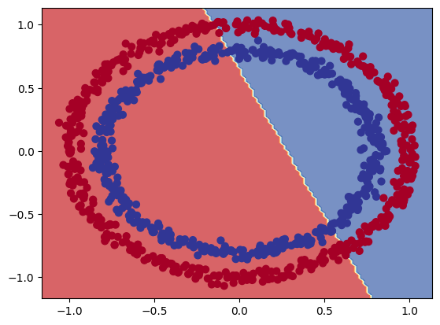

```python
# Check out the predictions our model is making
plot_decision_boundary(model_3, X, y)
```

Looks like our model wants to draw a straight line through it, but it's obvious our data can't be separated into a straight line.

However this may work efectively for a regression problem. Let's try it.

```python
# Set random seed
tf.random.set_seed(42)

# Create some regression data
X_regression = np.arange(0, 1000, 5)
y_regression = np.arange(100, 1100, 5)

# Split it into training and test sets
X_reg_train = X_regression[:150]
X_reg_test = X_regression[150:]
y_reg_train = y_regression[:150]
y_reg_test = y_regression[150:]

# Fit our model to the data
model_3.fit(tf.expand_dims(X_reg_train, axis=-1), y_reg_train, epochs=100)
```

[output not shown]

```python
model_3.summary()
```

```
Model: "sequential_2"
```

```
┏━━━━━━━━━━━━━━━━━━━━━━━━━━━━━━━━━┳━━━━━━━━━━━━━━━━━━━━━━━━┳━━━━━━━━━━━━━━━┓
┃ Layer (type)                    ┃ Output Shape           ┃       Param # ┃
┡━━━━━━━━━━━━━━━━━━━━━━━━━━━━━━━━━╇━━━━━━━━━━━━━━━━━━━━━━━━╇━━━━━━━━━━━━━━━┩
│ dense_3 (Dense)                 │ (None, 100)            │           300 │
├─────────────────────────────────┼────────────────────────┼───────────────┤
│ dense_4 (Dense)                 │ (None, 10)             │         1,010 │
├─────────────────────────────────┼────────────────────────┼───────────────┤
│ dense_5 (Dense)                 │ (None, 1)              │            11 │
└─────────────────────────────────┴────────────────────────┴───────────────┘
```

```
 Total params: 3,965 (15.49 KB)
```

```
 Trainable params: 1,321 (5.16 KB)
```

```
 Non-trainable params: 0 (0.00 B)
```

```
 Optimizer params: 2,644 (10.33 KB)
```

Problem is, the compiling was for binary classification problem. So let's change it to a regression problem.

```python
tf.random.set_seed(42)

model_3 = tf.keras.Sequential([
    tf.keras.layers.Dense(100),
    tf.keras.layers.Dense(10),
    tf.keras.layers.Dense(1)
])

model_3.compile(loss=tf.keras.losses.mae,
                optimizer=tf.keras.optimizers.Adam(),
                metrics=['mae'])

model_3.fit(tf.expand_dims(X_reg_train, axis=-1), y_reg_train, epochs=100)
```

```
5/5 ━━━━━━━━━━━━━━━━━━━━ 3s 18ms/step - loss: 452.3799 - mae: 452.3799
5/5 ━━━━━━━━━━━━━━━━━━━━ 0s 22ms/step - loss: 349.9195 - mae: 349.9195
5/5 ━━━━━━━━━━━━━━━━━━━━ 0s 15ms/step - loss: 246.3841 - mae: 246.3841
5/5 ━━━━━━━━━━━━━━━━━━━━ 0s 14ms/step - loss: 139.6722 - mae: 139.6722
5/5 ━━━━━━━━━━━━━━━━━━━━ 0s 16ms/step - loss: 47.8843 - mae: 47.8843
5/5 ━━━━━━━━━━━━━━━━━━━━ 0s 10ms/step - loss: 77.7163 - mae: 77.7163
5/5 ━━━━━━━━━━━━━━━━━━━━ 0s 12ms/step - loss: 78.0953 - mae: 78.0953
5/5 ━━━━━━━━━━━━━━━━━━━━ 0s 11ms/step - loss: 50.9845 - mae: 50.9845
5/5 ━━━━━━━━━━━━━━━━━━━━ 0s 15ms/step - loss: 45.1616 - mae: 45.1616
5/5 ━━━━━━━━━━━━━━━━━━━━ 0s 13ms/step - loss: 43.8440 - mae: 43.8440
5/5 ━━━━━━━━━━━━━━━━━━━━ 0s 11ms/step - loss: 42.6481 - mae: 42.6481
5/5 ━━━━━━━━━━━━━━━━━━━━ 0s 11ms/step - loss: 43.9203 - mae: 43.9203
5/5 ━━━━━━━━━━━━━━━━━━━━ 0s 10ms/step - loss: 40.2198 - mae: 40.2198
5/5 ━━━━━━━━━━━━━━━━━━━━ 0s 16ms/step - loss: 40.8847 - mae: 40.8847
5/5 ━━━━━━━━━━━━━━━━━━━━ 0s 10ms/step - loss: 39.9343 - mae: 39.9343
5/5 ━━━━━━━━━━━━━━━━━━━━ 0s 12ms/step - loss: 40.4780 - mae: 40.4780
5/5 ━━━━━━━━━━━━━━━━━━━━ 0s 13ms/step - loss: 39.9494 - mae: 39.9494
5/5 ━━━━━━━━━━━━━━━━━━━━ 0s 15ms/step - loss: 39.9870 - mae: 39.9870
5/5 ━━━━━━━━━━━━━━━━━━━━ 0s 11ms/step - loss: 39.9138 - mae: 39.9138
5/5 ━━━━━━━━━━━━━━━━━━━━ 0s 17ms/step - loss: 39.7698 - mae: 39.7698
5/5 ━━━━━━━━━━━━━━━━━━━━ 0s 12ms/step - loss: 39.7864 - mae: 39.7864
5/5 ━━━━━━━━━━━━━━━━━━━━ 0s 12ms/step - loss: 39.7541 - mae: 39.7541
5/5 ━━━━━━━━━━━━━━━━━━━━ 0s 14ms/step - loss: 39.7193 - mae: 39.7193
5/5 ━━━━━━━━━━━━━━━━━━━━ 0s 12ms/step - loss: 39.6861 - mae: 39.6861
5/5 ━━━━━━━━━━━━━━━━━━━━ 0s 12ms/step - loss: 39.6733 - mae: 39.6733
5/5 ━━━━━━━━━━━━━━━━━━━━ 0s 10ms/step - loss: 39.6708 - mae: 39.6708
5/5 ━━━━━━━━━━━━━━━━━━━━ 0s 15ms/step - loss: 39.6042 - mae: 39.6042
5/5 ━━━━━━━━━━━━━━━━━━━━ 0s 16ms/step - loss: 39.5883 - mae: 39.5883
5/5 ━━━━━━━━━━━━━━━━━━━━ 0s 11ms/step - loss: 39.5837 - mae: 39.5837
5/5 ━━━━━━━━━━━━━━━━━━━━ 0s 12ms/step - loss: 39.5359 - mae: 39.5359
5/5 ━━━━━━━━━━━━━━━━━━━━ 0s 11ms/step - loss: 39.5084 - mae: 39.5084
5/5 ━━━━━━━━━━━━━━━━━━━━ 0s 10ms/step - loss: 39.4815 - mae: 39.4815
5/5 ━━━━━━━━━━━━━━━━━━━━ 0s 10ms/step - loss: 39.4556 - mae: 39.4556
5/5 ━━━━━━━━━━━━━━━━━━━━ 0s 10ms/step - loss: 39.4499 - mae: 39.4499
5/5 ━━━━━━━━━━━━━━━━━━━━ 0s 18ms/step - loss: 39.4018 - mae: 39.4018
5/5 ━━━━━━━━━━━━━━━━━━━━ 0s 16ms/step - loss: 39.3741 - mae: 39.3741
5/5 ━━━━━━━━━━━━━━━━━━━━ 0s 12ms/step - loss: 39.3609 - mae: 39.3609
5/5 ━━━━━━━━━━━━━━━━━━━━ 0s 10ms/step - loss: 39.3523 - mae: 39.3523
5/5 ━━━━━━━━━━━━━━━━━━━━ 0s 11ms/step - loss: 39.2751 - mae: 39.2751
5/5 ━━━━━━━━━━━━━━━━━━━━ 0s 9ms/step - loss: 39.2666 - mae: 39.2666
```

[output cut: 45 more lines]

```
5/5 ━━━━━━━━━━━━━━━━━━━━ 0s 11ms/step - loss: 37.7880 - mae: 37.7880
5/5 ━━━━━━━━━━━━━━━━━━━━ 0s 9ms/step - loss: 37.7304 - mae: 37.7304
5/5 ━━━━━━━━━━━━━━━━━━━━ 0s 11ms/step - loss: 37.7349 - mae: 37.7349
5/5 ━━━━━━━━━━━━━━━━━━━━ 0s 9ms/step - loss: 37.6592 - mae: 37.6592
5/5 ━━━━━━━━━━━━━━━━━━━━ 0s 9ms/step - loss: 37.6083 - mae: 37.6083
5/5 ━━━━━━━━━━━━━━━━━━━━ 0s 12ms/step - loss: 37.6040 - mae: 37.6040
5/5 ━━━━━━━━━━━━━━━━━━━━ 0s 11ms/step - loss: 37.5531 - mae: 37.5531
5/5 ━━━━━━━━━━━━━━━━━━━━ 0s 12ms/step - loss: 37.4997 - mae: 37.4997
5/5 ━━━━━━━━━━━━━━━━━━━━ 0s 11ms/step - loss: 37.4634 - mae: 37.4634
5/5 ━━━━━━━━━━━━━━━━━━━━ 0s 9ms/step - loss: 37.4183 - mae: 37.4183
5/5 ━━━━━━━━━━━━━━━━━━━━ 0s 9ms/step - loss: 37.4158 - mae: 37.4158
5/5 ━━━━━━━━━━━━━━━━━━━━ 0s 8ms/step - loss: 37.3648 - mae: 37.3648
5/5 ━━━━━━━━━━━━━━━━━━━━ 0s 11ms/step - loss: 37.2589 - mae: 37.2589
5/5 ━━━━━━━━━━━━━━━━━━━━ 0s 9ms/step - loss: 37.2611 - mae: 37.2611
5/5 ━━━━━━━━━━━━━━━━━━━━ 0s 9ms/step - loss: 37.2319 - mae: 37.2319
```

```
<keras.src.callbacks.history.History at 0x2ae29712d00>
```

Seems like the model is learning something, as the `mae` is slowly trending down.

```
2/2 ━━━━━━━━━━━━━━━━━━━━ 0s 68ms/step
```

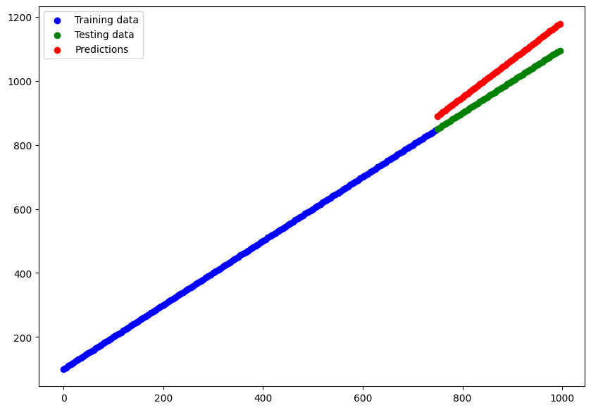

```python
# Make predictions with out trained model
y_reg_preds = model_3.predict(X_reg_test)

# Plot the model's predictions against our regression data
plt.figure(figsize=(10,7))
plt.scatter(X_reg_train, y_reg_train, c='b', label='Training data')
plt.scatter(X_reg_test, y_reg_test, c='g', label='Testing data')
plt.scatter(X_reg_test, y_reg_preds.squeeze(), c='r', label='Predictions')
plt.legend();
```

The prediction is not perfect, but it is getting close to the answer.

There must be something still missing with our circle classification problem...

### The missing piece: Non-linearity

So we can see the neural network able to model straight lines with abit of guessing/variability. But what about non-straight lines?

To model our classification data, we're going to need some non-linear lines.

The main change we'll add to the model is use the `activation` keyword.

```python
tf.random.set_seed(42)

model_4 = tf.keras.Sequential([
    tf.keras.layers.Dense(1, activation=tf.keras.activations.linear), # 1 hidden layer with linear activation
    tf.keras.layers.Dense(1) # output layer
])

model_4.compile(loss=tf.keras.losses.binary_crossentropy,
                optimizer=tf.keras.optimizers.Adam(learning_rate=0.001),
                metrics=['accuracy'])

history = model_4.fit(X, y, epochs=100)
```

```
32/32 ━━━━━━━━━━━━━━━━━━━━ 1s 4ms/step - accuracy: 0.4830 - loss: 4.4879
32/32 ━━━━━━━━━━━━━━━━━━━━ 0s 3ms/step - accuracy: 0.4830 - loss: 4.3201
32/32 ━━━━━━━━━━━━━━━━━━━━ 0s 3ms/step - accuracy: 0.4830 - loss: 4.2049
32/32 ━━━━━━━━━━━━━━━━━━━━ 0s 3ms/step - accuracy: 0.4830 - loss: 4.1283
32/32 ━━━━━━━━━━━━━━━━━━━━ 0s 4ms/step - accuracy: 0.4830 - loss: 4.0889
32/32 ━━━━━━━━━━━━━━━━━━━━ 0s 3ms/step - accuracy: 0.4830 - loss: 4.0367
32/32 ━━━━━━━━━━━━━━━━━━━━ 0s 3ms/step - accuracy: 0.4830 - loss: 3.9303
32/32 ━━━━━━━━━━━━━━━━━━━━ 0s 3ms/step - accuracy: 0.4830 - loss: 3.7707
32/32 ━━━━━━━━━━━━━━━━━━━━ 0s 3ms/step - accuracy: 0.4830 - loss: 3.6747
32/32 ━━━━━━━━━━━━━━━━━━━━ 0s 3ms/step - accuracy: 0.4830 - loss: 3.5406
32/32 ━━━━━━━━━━━━━━━━━━━━ 0s 3ms/step - accuracy: 0.4830 - loss: 3.4381
32/32 ━━━━━━━━━━━━━━━━━━━━ 0s 3ms/step - accuracy: 0.4830 - loss: 3.3227
32/32 ━━━━━━━━━━━━━━━━━━━━ 0s 4ms/step - accuracy: 0.4830 - loss: 2.8620
32/32 ━━━━━━━━━━━━━━━━━━━━ 0s 3ms/step - accuracy: 0.4830 - loss: 2.5334
32/32 ━━━━━━━━━━━━━━━━━━━━ 0s 3ms/step - accuracy: 0.4830 - loss: 2.3029
32/32 ━━━━━━━━━━━━━━━━━━━━ 0s 3ms/step - accuracy: 0.4830 - loss: 1.1653
32/32 ━━━━━━━━━━━━━━━━━━━━ 0s 4ms/step - accuracy: 0.4830 - loss: 1.0872
32/32 ━━━━━━━━━━━━━━━━━━━━ 0s 3ms/step - accuracy: 0.4830 - loss: 1.0619
32/32 ━━━━━━━━━━━━━━━━━━━━ 0s 3ms/step - accuracy: 0.4830 - loss: 1.0428
32/32 ━━━━━━━━━━━━━━━━━━━━ 0s 3ms/step - accuracy: 0.4830 - loss: 1.0269
32/32 ━━━━━━━━━━━━━━━━━━━━ 0s 3ms/step - accuracy: 0.4830 - loss: 1.0129
32/32 ━━━━━━━━━━━━━━━━━━━━ 0s 3ms/step - accuracy: 0.4830 - loss: 1.0005
32/32 ━━━━━━━━━━━━━━━━━━━━ 0s 3ms/step - accuracy: 0.4830 - loss: 0.9892
32/32 ━━━━━━━━━━━━━━━━━━━━ 0s 3ms/step - accuracy: 0.4830 - loss: 0.9789
32/32 ━━━━━━━━━━━━━━━━━━━━ 0s 3ms/step - accuracy: 0.4830 - loss: 0.9692
32/32 ━━━━━━━━━━━━━━━━━━━━ 0s 3ms/step - accuracy: 0.4830 - loss: 0.9602
32/32 ━━━━━━━━━━━━━━━━━━━━ 0s 3ms/step - accuracy: 0.4830 - loss: 0.9517
32/32 ━━━━━━━━━━━━━━━━━━━━ 0s 4ms/step - accuracy: 0.4830 - loss: 0.9437
32/32 ━━━━━━━━━━━━━━━━━━━━ 0s 3ms/step - accuracy: 0.4830 - loss: 0.9361
32/32 ━━━━━━━━━━━━━━━━━━━━ 0s 2ms/step - accuracy: 0.4830 - loss: 0.9288
32/32 ━━━━━━━━━━━━━━━━━━━━ 0s 3ms/step - accuracy: 0.4830 - loss: 0.9219
32/32 ━━━━━━━━━━━━━━━━━━━━ 0s 3ms/step - accuracy: 0.4830 - loss: 0.9152
32/32 ━━━━━━━━━━━━━━━━━━━━ 0s 3ms/step - accuracy: 0.4830 - loss: 0.9088
32/32 ━━━━━━━━━━━━━━━━━━━━ 0s 3ms/step - accuracy: 0.4830 - loss: 0.9026
32/32 ━━━━━━━━━━━━━━━━━━━━ 0s 3ms/step - accuracy: 0.4830 - loss: 0.8967
32/32 ━━━━━━━━━━━━━━━━━━━━ 0s 3ms/step - accuracy: 0.4830 - loss: 0.8909
32/32 ━━━━━━━━━━━━━━━━━━━━ 0s 3ms/step - accuracy: 0.4830 - loss: 0.8854
32/32 ━━━━━━━━━━━━━━━━━━━━ 0s 3ms/step - accuracy: 0.4830 - loss: 0.8800
32/32 ━━━━━━━━━━━━━━━━━━━━ 0s 3ms/step - accuracy: 0.4830 - loss: 0.8748
32/32 ━━━━━━━━━━━━━━━━━━━━ 0s 3ms/step - accuracy: 0.4830 - loss: 0.8697
```

[output cut: 45 more lines]

```
32/32 ━━━━━━━━━━━━━━━━━━━━ 0s 4ms/step - accuracy: 0.4830 - loss: 0.7336
32/32 ━━━━━━━━━━━━━━━━━━━━ 0s 4ms/step - accuracy: 0.4830 - loss: 0.7320
32/32 ━━━━━━━━━━━━━━━━━━━━ 0s 4ms/step - accuracy: 0.4830 - loss: 0.7305
32/32 ━━━━━━━━━━━━━━━━━━━━ 0s 4ms/step - accuracy: 0.4830 - loss: 0.7291
32/32 ━━━━━━━━━━━━━━━━━━━━ 0s 3ms/step - accuracy: 0.4830 - loss: 0.7276
32/32 ━━━━━━━━━━━━━━━━━━━━ 0s 3ms/step - accuracy: 0.4830 - loss: 0.7263
32/32 ━━━━━━━━━━━━━━━━━━━━ 0s 3ms/step - accuracy: 0.4830 - loss: 0.7249
32/32 ━━━━━━━━━━━━━━━━━━━━ 0s 3ms/step - accuracy: 0.4830 - loss: 0.7236
32/32 ━━━━━━━━━━━━━━━━━━━━ 0s 3ms/step - accuracy: 0.4830 - loss: 0.7224
32/32 ━━━━━━━━━━━━━━━━━━━━ 0s 4ms/step - accuracy: 0.4830 - loss: 0.7211
32/32 ━━━━━━━━━━━━━━━━━━━━ 0s 4ms/step - accuracy: 0.4830 - loss: 0.7200
32/32 ━━━━━━━━━━━━━━━━━━━━ 0s 3ms/step - accuracy: 0.4830 - loss: 0.7188
32/32 ━━━━━━━━━━━━━━━━━━━━ 0s 3ms/step - accuracy: 0.4830 - loss: 0.7177
32/32 ━━━━━━━━━━━━━━━━━━━━ 0s 3ms/step - accuracy: 0.4830 - loss: 0.7166
32/32 ━━━━━━━━━━━━━━━━━━━━ 0s 3ms/step - accuracy: 0.4830 - loss: 0.7156
```

```
WARNING:tensorflow:5 out of the last 316 calls to <function TensorFlowTrainer.make_predict_function.<locals>.one_step_on_data_distributed at 0x000002AE29A57D30> triggered tf.function retracing. Tracing is expensive and the excessive number of tracings could be due to (1) creating @tf.function repeat…
313/313 ━━━━━━━━━━━━━━━━━━━━ 1s 1ms/step
doing binary classification...
```

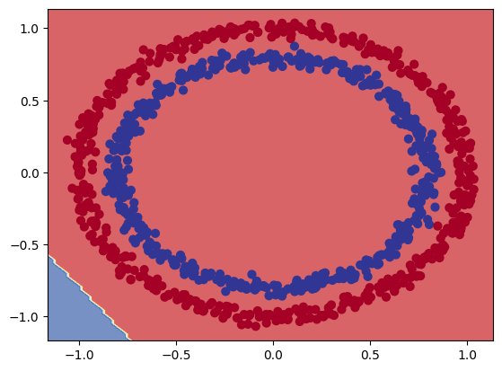

```python
# Check the decision boundary of the new model
plot_decision_boundary(model_4, X, y)
```

It looks to give a straight line prediction again.

So we'll add some non-linearity to the model, and use other `activation` parameters in out layers.

```python
tf.random.set_seed(42)

model_5 = tf.keras.Sequential([
    tf.keras.layers.Dense(1, activation=tf.keras.activations.relu),
    tf.keras.layers.Dense(1)
])

model_5.compile(loss=tf.keras.losses.binary_crossentropy,
                optimizer=tf.keras.optimizers.Adam(),
                metrics=['accuracy'])

history = model_5.fit(X, y, epochs=100)
```

```
32/32 ━━━━━━━━━━━━━━━━━━━━ 2s 4ms/step - accuracy: 0.4463 - loss: 4.0542
32/32 ━━━━━━━━━━━━━━━━━━━━ 0s 3ms/step - accuracy: 0.4451 - loss: 3.0905
32/32 ━━━━━━━━━━━━━━━━━━━━ 0s 3ms/step - accuracy: 0.4451 - loss: 2.9294
32/32 ━━━━━━━━━━━━━━━━━━━━ 0s 3ms/step - accuracy: 0.4430 - loss: 2.8273
32/32 ━━━━━━━━━━━━━━━━━━━━ 0s 3ms/step - accuracy: 0.4431 - loss: 2.6369
32/32 ━━━━━━━━━━━━━━━━━━━━ 0s 3ms/step - accuracy: 0.4474 - loss: 2.4136
32/32 ━━━━━━━━━━━━━━━━━━━━ 0s 3ms/step - accuracy: 0.4450 - loss: 2.1383
32/32 ━━━━━━━━━━━━━━━━━━━━ 0s 3ms/step - accuracy: 0.4462 - loss: 1.7646
32/32 ━━━━━━━━━━━━━━━━━━━━ 0s 3ms/step - accuracy: 0.4494 - loss: 1.4050
32/32 ━━━━━━━━━━━━━━━━━━━━ 0s 3ms/step - accuracy: 0.4463 - loss: 1.3662
32/32 ━━━━━━━━━━━━━━━━━━━━ 0s 3ms/step - accuracy: 0.4463 - loss: 1.3341
32/32 ━━━━━━━━━━━━━━━━━━━━ 0s 3ms/step - accuracy: 0.4463 - loss: 1.3059
32/32 ━━━━━━━━━━━━━━━━━━━━ 0s 4ms/step - accuracy: 0.4463 - loss: 1.2806
32/32 ━━━━━━━━━━━━━━━━━━━━ 0s 3ms/step - accuracy: 0.4461 - loss: 1.2578
32/32 ━━━━━━━━━━━━━━━━━━━━ 0s 3ms/step - accuracy: 0.4461 - loss: 1.2370
32/32 ━━━━━━━━━━━━━━━━━━━━ 0s 3ms/step - accuracy: 0.4461 - loss: 1.2178
32/32 ━━━━━━━━━━━━━━━━━━━━ 0s 4ms/step - accuracy: 0.4459 - loss: 1.2000
32/32 ━━━━━━━━━━━━━━━━━━━━ 0s 3ms/step - accuracy: 0.4465 - loss: 1.1833
32/32 ━━━━━━━━━━━━━━━━━━━━ 0s 3ms/step - accuracy: 0.4397 - loss: 1.1676
32/32 ━━━━━━━━━━━━━━━━━━━━ 0s 3ms/step - accuracy: 0.4393 - loss: 1.1527
32/32 ━━━━━━━━━━━━━━━━━━━━ 0s 3ms/step - accuracy: 0.4389 - loss: 1.1387
32/32 ━━━━━━━━━━━━━━━━━━━━ 0s 3ms/step - accuracy: 0.4415 - loss: 1.1255
32/32 ━━━━━━━━━━━━━━━━━━━━ 0s 4ms/step - accuracy: 0.4418 - loss: 1.1129
32/32 ━━━━━━━━━━━━━━━━━━━━ 0s 4ms/step - accuracy: 0.4429 - loss: 1.1010
32/32 ━━━━━━━━━━━━━━━━━━━━ 0s 4ms/step - accuracy: 0.4429 - loss: 1.0896
32/32 ━━━━━━━━━━━━━━━━━━━━ 0s 3ms/step - accuracy: 0.4417 - loss: 1.0787
32/32 ━━━━━━━━━━━━━━━━━━━━ 0s 3ms/step - accuracy: 0.4417 - loss: 1.0684
32/32 ━━━━━━━━━━━━━━━━━━━━ 0s 3ms/step - accuracy: 0.4417 - loss: 1.0584
32/32 ━━━━━━━━━━━━━━━━━━━━ 0s 3ms/step - accuracy: 0.4417 - loss: 1.0488
32/32 ━━━━━━━━━━━━━━━━━━━━ 0s 3ms/step - accuracy: 0.4410 - loss: 1.0396
32/32 ━━━━━━━━━━━━━━━━━━━━ 0s 3ms/step - accuracy: 0.4410 - loss: 1.0308
32/32 ━━━━━━━━━━━━━━━━━━━━ 0s 3ms/step - accuracy: 0.4410 - loss: 1.0222
32/32 ━━━━━━━━━━━━━━━━━━━━ 0s 3ms/step - accuracy: 0.4410 - loss: 1.0140
32/32 ━━━━━━━━━━━━━━━━━━━━ 0s 3ms/step - accuracy: 0.4410 - loss: 1.0061
32/32 ━━━━━━━━━━━━━━━━━━━━ 0s 3ms/step - accuracy: 0.4404 - loss: 0.9984
32/32 ━━━━━━━━━━━━━━━━━━━━ 0s 4ms/step - accuracy: 0.4400 - loss: 0.9909
32/32 ━━━━━━━━━━━━━━━━━━━━ 0s 4ms/step - accuracy: 0.4400 - loss: 0.9836
32/32 ━━━━━━━━━━━━━━━━━━━━ 0s 3ms/step - accuracy: 0.4400 - loss: 0.9765
32/32 ━━━━━━━━━━━━━━━━━━━━ 0s 3ms/step - accuracy: 0.4395 - loss: 0.9696
32/32 ━━━━━━━━━━━━━━━━━━━━ 0s 3ms/step - accuracy: 0.4398 - loss: 0.9627
```

[output cut: 45 more lines]

```
32/32 ━━━━━━━━━━━━━━━━━━━━ 0s 3ms/step - accuracy: 0.4181 - loss: 0.7731
32/32 ━━━━━━━━━━━━━━━━━━━━ 0s 4ms/step - accuracy: 0.4165 - loss: 0.7707
32/32 ━━━━━━━━━━━━━━━━━━━━ 0s 3ms/step - accuracy: 0.4163 - loss: 0.7683
32/32 ━━━━━━━━━━━━━━━━━━━━ 0s 3ms/step - accuracy: 0.4128 - loss: 0.7659
32/32 ━━━━━━━━━━━━━━━━━━━━ 0s 3ms/step - accuracy: 0.4082 - loss: 0.7636
32/32 ━━━━━━━━━━━━━━━━━━━━ 0s 3ms/step - accuracy: 0.4048 - loss: 0.7613
32/32 ━━━━━━━━━━━━━━━━━━━━ 0s 3ms/step - accuracy: 0.4037 - loss: 0.7591
32/32 ━━━━━━━━━━━━━━━━━━━━ 0s 3ms/step - accuracy: 0.4047 - loss: 0.7568
32/32 ━━━━━━━━━━━━━━━━━━━━ 0s 4ms/step - accuracy: 0.4035 - loss: 0.7546
32/32 ━━━━━━━━━━━━━━━━━━━━ 0s 4ms/step - accuracy: 0.4026 - loss: 0.7524
32/32 ━━━━━━━━━━━━━━━━━━━━ 0s 3ms/step - accuracy: 0.3990 - loss: 0.7502
32/32 ━━━━━━━━━━━━━━━━━━━━ 0s 3ms/step - accuracy: 0.3985 - loss: 0.7481
32/32 ━━━━━━━━━━━━━━━━━━━━ 0s 3ms/step - accuracy: 0.3968 - loss: 0.7460
32/32 ━━━━━━━━━━━━━━━━━━━━ 0s 3ms/step - accuracy: 0.3933 - loss: 0.7440
32/32 ━━━━━━━━━━━━━━━━━━━━ 0s 3ms/step - accuracy: 0.3876 - loss: 0.7421
```

Doesn't seem to help...

How about increasing the number of neurons and layers, say, 2 hidden layers with ReLU, and 4 neurons each?

We can see that in actions with `TensorFlow Playground demo`.

[figure not shown]

```python
tf.random.set_seed(42)

model_6 = tf.keras.Sequential([
    tf.keras.layers.Dense(4, activation=tf.keras.activations.relu), # hidden layer 1, 4 neurons, ReLU activation
    tf.keras.layers.Dense(4, activation=tf.keras.activations.relu), # hidden layer 2, 4 neurons, ReLU activation
    tf.keras.layers.Dense(1) # output layer
])

model_6.compile(loss=tf.keras.losses.binary_crossentropy,
                optimizer=tf.keras.optimizers.Adam(learning_rate=0.001),
                metrics=['accuracy'])

history = model_6.fit(X, y, epochs=100)
```

```
32/32 ━━━━━━━━━━━━━━━━━━━━ 2s 3ms/step - accuracy: 0.4072 - loss: 2.6570
32/32 ━━━━━━━━━━━━━━━━━━━━ 0s 4ms/step - accuracy: 0.4182 - loss: 2.2015
32/32 ━━━━━━━━━━━━━━━━━━━━ 0s 3ms/step - accuracy: 0.4129 - loss: 1.1555
32/32 ━━━━━━━━━━━━━━━━━━━━ 0s 4ms/step - accuracy: 0.4110 - loss: 0.9934
32/32 ━━━━━━━━━━━━━━━━━━━━ 0s 4ms/step - accuracy: 0.4208 - loss: 0.9530
32/32 ━━━━━━━━━━━━━━━━━━━━ 0s 3ms/step - accuracy: 0.4128 - loss: 0.9206
32/32 ━━━━━━━━━━━━━━━━━━━━ 0s 3ms/step - accuracy: 0.4101 - loss: 0.8946
32/32 ━━━━━━━━━━━━━━━━━━━━ 0s 3ms/step - accuracy: 0.3983 - loss: 0.8731
32/32 ━━━━━━━━━━━━━━━━━━━━ 0s 3ms/step - accuracy: 0.4001 - loss: 0.8557
32/32 ━━━━━━━━━━━━━━━━━━━━ 0s 3ms/step - accuracy: 0.3996 - loss: 0.8410
32/32 ━━━━━━━━━━━━━━━━━━━━ 0s 3ms/step - accuracy: 0.4072 - loss: 0.8283
32/32 ━━━━━━━━━━━━━━━━━━━━ 0s 4ms/step - accuracy: 0.4025 - loss: 0.8169
32/32 ━━━━━━━━━━━━━━━━━━━━ 0s 3ms/step - accuracy: 0.3977 - loss: 0.8063
32/32 ━━━━━━━━━━━━━━━━━━━━ 0s 3ms/step - accuracy: 0.3910 - loss: 0.7970
32/32 ━━━━━━━━━━━━━━━━━━━━ 0s 4ms/step - accuracy: 0.3803 - loss: 0.7883
32/32 ━━━━━━━━━━━━━━━━━━━━ 0s 4ms/step - accuracy: 0.3719 - loss: 0.7796
32/32 ━━━━━━━━━━━━━━━━━━━━ 0s 4ms/step - accuracy: 0.3592 - loss: 0.7709
32/32 ━━━━━━━━━━━━━━━━━━━━ 0s 3ms/step - accuracy: 0.3403 - loss: 0.7637
32/32 ━━━━━━━━━━━━━━━━━━━━ 0s 3ms/step - accuracy: 0.3262 - loss: 0.7571
32/32 ━━━━━━━━━━━━━━━━━━━━ 0s 3ms/step - accuracy: 0.3157 - loss: 0.7510
32/32 ━━━━━━━━━━━━━━━━━━━━ 0s 3ms/step - accuracy: 0.2924 - loss: 0.7456
32/32 ━━━━━━━━━━━━━━━━━━━━ 0s 3ms/step - accuracy: 0.2848 - loss: 0.7396
32/32 ━━━━━━━━━━━━━━━━━━━━ 0s 3ms/step - accuracy: 0.2881 - loss: 0.7334
32/32 ━━━━━━━━━━━━━━━━━━━━ 0s 3ms/step - accuracy: 0.2596 - loss: 0.7299
32/32 ━━━━━━━━━━━━━━━━━━━━ 0s 3ms/step - accuracy: 0.2841 - loss: 0.7262
32/32 ━━━━━━━━━━━━━━━━━━━━ 0s 4ms/step - accuracy: 0.3321 - loss: 0.7226
32/32 ━━━━━━━━━━━━━━━━━━━━ 0s 4ms/step - accuracy: 0.4113 - loss: 0.7179
32/32 ━━━━━━━━━━━━━━━━━━━━ 0s 4ms/step - accuracy: 0.4646 - loss: 0.7099
32/32 ━━━━━━━━━━━━━━━━━━━━ 0s 3ms/step - accuracy: 0.4692 - loss: 0.7074
32/32 ━━━━━━━━━━━━━━━━━━━━ 0s 3ms/step - accuracy: 0.4903 - loss: 0.7047
32/32 ━━━━━━━━━━━━━━━━━━━━ 0s 3ms/step - accuracy: 0.4935 - loss: 0.7021
32/32 ━━━━━━━━━━━━━━━━━━━━ 0s 4ms/step - accuracy: 0.4985 - loss: 0.6997
32/32 ━━━━━━━━━━━━━━━━━━━━ 0s 3ms/step - accuracy: 0.5009 - loss: 0.6975
32/32 ━━━━━━━━━━━━━━━━━━━━ 0s 3ms/step - accuracy: 0.5049 - loss: 0.6955
32/32 ━━━━━━━━━━━━━━━━━━━━ 0s 3ms/step - accuracy: 0.5125 - loss: 0.6937
32/32 ━━━━━━━━━━━━━━━━━━━━ 0s 3ms/step - accuracy: 0.5068 - loss: 0.6919
32/32 ━━━━━━━━━━━━━━━━━━━━ 0s 3ms/step - accuracy: 0.5247 - loss: 0.6904
32/32 ━━━━━━━━━━━━━━━━━━━━ 0s 3ms/step - accuracy: 0.5216 - loss: 0.6889
32/32 ━━━━━━━━━━━━━━━━━━━━ 0s 4ms/step - accuracy: 0.5257 - loss: 0.6876
32/32 ━━━━━━━━━━━━━━━━━━━━ 0s 4ms/step - accuracy: 0.5207 - loss: 0.6864
```

[output cut: 45 more lines]

```
32/32 ━━━━━━━━━━━━━━━━━━━━ 0s 3ms/step - accuracy: 0.5695 - loss: 0.6510
32/32 ━━━━━━━━━━━━━━━━━━━━ 0s 4ms/step - accuracy: 0.5676 - loss: 0.6493
32/32 ━━━━━━━━━━━━━━━━━━━━ 0s 3ms/step - accuracy: 0.5733 - loss: 0.6474
32/32 ━━━━━━━━━━━━━━━━━━━━ 0s 3ms/step - accuracy: 0.5766 - loss: 0.6454
32/32 ━━━━━━━━━━━━━━━━━━━━ 0s 3ms/step - accuracy: 0.5796 - loss: 0.6434
32/32 ━━━━━━━━━━━━━━━━━━━━ 0s 3ms/step - accuracy: 0.5799 - loss: 0.6412
32/32 ━━━━━━━━━━━━━━━━━━━━ 0s 4ms/step - accuracy: 0.5885 - loss: 0.6387
32/32 ━━━━━━━━━━━━━━━━━━━━ 0s 4ms/step - accuracy: 0.5929 - loss: 0.6360
32/32 ━━━━━━━━━━━━━━━━━━━━ 0s 4ms/step - accuracy: 0.5963 - loss: 0.6332
32/32 ━━━━━━━━━━━━━━━━━━━━ 0s 4ms/step - accuracy: 0.5970 - loss: 0.6304
32/32 ━━━━━━━━━━━━━━━━━━━━ 0s 3ms/step - accuracy: 0.6008 - loss: 0.6273
32/32 ━━━━━━━━━━━━━━━━━━━━ 0s 4ms/step - accuracy: 0.6091 - loss: 0.6240
32/32 ━━━━━━━━━━━━━━━━━━━━ 0s 4ms/step - accuracy: 0.6221 - loss: 0.6205
32/32 ━━━━━━━━━━━━━━━━━━━━ 0s 3ms/step - accuracy: 0.6367 - loss: 0.6169
32/32 ━━━━━━━━━━━━━━━━━━━━ 0s 4ms/step - accuracy: 0.6444 - loss: 0.6131
```

Wow, this time the accuracy is actually looking promising! Let's see it in graph form.

```
313/313 ━━━━━━━━━━━━━━━━━━━━ 1s 2ms/step
doing binary classification...
```

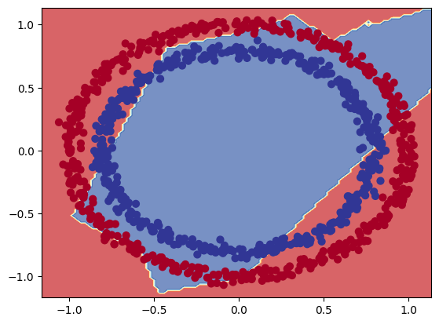

```python
plot_decision_boundary(model_6, X, y)
```

We can see how it still draws straight lines, but at least, they have corners to these. Creating seperate straight lines.

Ideally we want that thin yellow line go in between the red and blue circle.

We'll change the activation functionon our output layer too. Remember that binary classification output layer activation, is usually the `Sigmoid activation function`.

```python
tf.random.set_seed(42)

model_7 = tf.keras.Sequential([
    tf.keras.layers.Dense(4, activation=tf.keras.activations.relu),
    tf.keras.layers.Dense(4, activation=tf.keras.activations.relu),
    tf.keras.layers.Dense(1, activation=tf.keras.activations.sigmoid) # output layer, sigmoid activation
])

model_7.compile(loss=tf.keras.losses.binary_crossentropy,
                optimizer=tf.keras.optimizers.Adam(),
                metrics=['accuracy'])

history = model_7.fit(X, y, epochs=100, verbose=0)
```

```python
# Evaluate our model
model_7.evaluate(X, y)
```

```
32/32 ━━━━━━━━━━━━━━━━━━━━ 0s 3ms/step - accuracy: 0.9144 - loss: 0.3774
```

```
[0.3746528625488281, 0.9150000214576721]
```

The model seems to get some incredible accuracy this time around! Let's check it out in graph form.

```
313/313 ━━━━━━━━━━━━━━━━━━━━ 1s 2ms/step
doing binary classification...
```

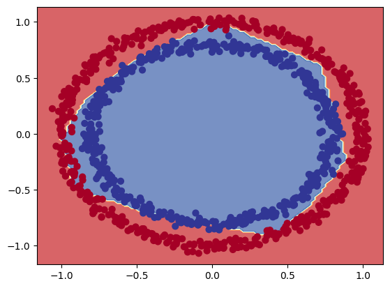

```python
# View prediction of the model with relu and sigmoid activations
plot_decision_boundary(model_7, X, y)
```

Model is near perfections! (Apart from a few examples)

> 🤔**Question**: What's wrong with the predictions we've made? Are we evaluating the model correctly? Hint: what data did the model learn on and what did we predict on?

Before we answer that, it's important to recognize what we've just covered.

> 📝**Note**: The combination of `linear` and `non-linear` functions is one of the kery fundamentals of neural networks.

For example:

What kind of patterns can you draw from straight and non-striaght lines? That's what neural network does to find patterns.

These linear and non-linear stuff is what powers the layers in the models we build.

To get better intuition of activation functions we've just used, let's create them and then try them on some toy(simple) data.

```python
# Create a toy tensor (similar to the data we pass intot our model)
A = tf.cast(tf.range(-10, 10), tf.float32) # -10 to 10 array
A
```

```
<tf.Tensor: shape=(20,), dtype=float32, numpy=
array([-10.,  -9.,  -8.,  -7.,  -6.,  -5.,  -4.,  -3.,  -2.,  -1.,   0.,
         1.,   2.,   3.,   4.,   5.,   6.,   7.,   8.,   9.],
      dtype=float32)>
```

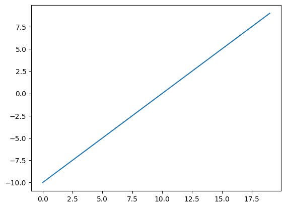

```python
# Visualize our toy tensor
plt.plot(A);
```

We have a straight line, now let's recreate the `sigmoid function` and see what it does to our data. There's also a pre-built sigmoid function at `tf.keras.activations.sigmoid`.

For now, we'll create it from scratch which is simple enough, and see what happens to y, after we give it the X dataset from -10 to 10.

```python
# Sigmoid - https://www.tensorflow.org/api_docs/python/tf/keras/activations/sigmoid
def sigmoid(x):
    return 1/(1+tf.exp(-x))

# use sigmoid function on our tensor
sigmoid(A)
```

```
<tf.Tensor: shape=(20,), dtype=float32, numpy=
array([4.5397872e-05, 1.2339458e-04, 3.3535014e-04, 9.1105117e-04,
       2.4726233e-03, 6.6928510e-03, 1.7986210e-02, 4.7425874e-02,
       1.1920292e-01, 2.6894143e-01, 5.0000000e-01, 7.3105860e-01,
       8.8079703e-01, 9.5257413e-01, 9.8201376e-01, 9.9330717e-01,
       9.9752742e-01, 9.9908900e-01, 9.9966466e-01, 9.9987662e-01],
      dtype=float32)>
```

How does it look?

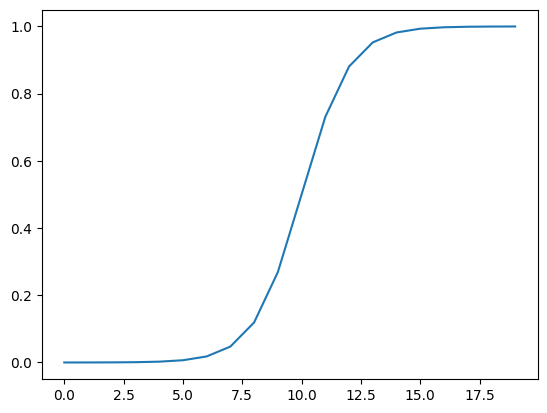

```python
plt.plot(sigmoid(A));
```

A non-straight line!

What about ReLU function? (As ReLU turns all negatives to 0 and positive number stay the same)

```python
# ReLU - https://www.tensorflow.org/api_docs/python/tf/keras/activations/relu
def relu(x):
    return tf.maximum(0, x)

# Pass toy tensor through ReLU function
relu(A)
```

```
<tf.Tensor: shape=(20,), dtype=float32, numpy=
array([0., 0., 0., 0., 0., 0., 0., 0., 0., 0., 0., 1., 2., 3., 4., 5., 6.,
       7., 8., 9.], dtype=float32)>
```

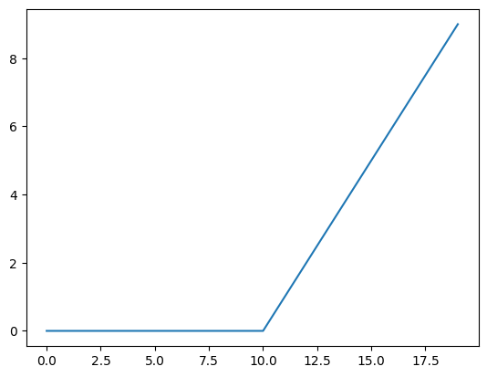

```python
# Plot ReLU-modeified tensor
plt.plot(relu(A));
```

We got non-straight line :)

How about TensorFlow's linear activation function?

```python
# Linear - https://www.tensorflow.org/api_docs/python/tf/keras/activations/linear (returns input non-modified...)
tf.keras.activations.linear(A)
```

```
<tf.Tensor: shape=(20,), dtype=float32, numpy=
array([-10.,  -9.,  -8.,  -7.,  -6.,  -5.,  -4.,  -3.,  -2.,  -1.,   0.,
         1.,   2.,   3.,   4.,   5.,   6.,   7.,   8.,   9.],
      dtype=float32)>
```

Hmm, it looks like our inputs are unmodified from X

```python
# Does the linear activation change anything?
A == tf.keras.activations.linear(A)
```

```
<tf.Tensor: shape=(20,), dtype=bool, numpy=
array([ True,  True,  True,  True,  True,  True,  True,  True,  True,
        True,  True,  True,  True,  True,  True,  True,  True,  True,
        True,  True])>
```

It makes sense how our model won't learn much when using only linear activation function, while our problem is not a linear one. So non-linear function incorporation, are capable to manipulate and shape around the data, once it starts to form its own pattern between the input and output.

There is a place to dive more deep into the guts of neural network: [Machine Learning Cheatsheet Page](https://ml-cheatsheet.readthedocs.io/en/latest/activation_functions.html#)

### Evaluating and improving our classification model

There is a problem with the way we are training. We're evaluating by the entire data set, rather than splitting it to training, validation, and test.

Once we've done that, we'll train the model on the training set, and then see how well it performs with predicting the data patterns on the test set.

```python
# how much examples in he whole dataset?
len(X)
```

```
1000
```

```python
# split data into train and test sets
X_train, y_train = X[:800], y[:800]
X_test, y_test = X[800:], y[800:]

# check shape of data
X_train.shape, y_train.shape
```

```
((800, 2), (800,))
```

Now we have the training and test sets, let's model upon the training data, and evaluate what our model has learnt with the test set.

```python
tf.random.set_seed(42)

model_8 = tf.keras.Sequential([
    tf.keras.layers.Dense(4, activation='relu'),
    tf.keras.layers.Dense(4, activation='relu'),
    tf.keras.layers.Dense(1, activation='sigmoid')
])

model_8.compile(loss=tf.keras.losses.binary_crossentropy,
                optimizer=tf.keras.optimizers.Adam(learning_rate=0.01), # increasing learning rate from 0.001 to 0.01 for faster learning
                metrics=['accuracy'])

history = model_8.fit(X_train, y_train, epochs=100)
```

```
25/25 ━━━━━━━━━━━━━━━━━━━━ 2s 4ms/step - accuracy: 0.4832 - loss: 0.6962
25/25 ━━━━━━━━━━━━━━━━━━━━ 0s 3ms/step - accuracy: 0.5002 - loss: 0.6890
25/25 ━━━━━━━━━━━━━━━━━━━━ 0s 3ms/step - accuracy: 0.5250 - loss: 0.6855
25/25 ━━━━━━━━━━━━━━━━━━━━ 0s 3ms/step - accuracy: 0.5843 - loss: 0.6802
25/25 ━━━━━━━━━━━━━━━━━━━━ 0s 3ms/step - accuracy: 0.5847 - loss: 0.6727
25/25 ━━━━━━━━━━━━━━━━━━━━ 0s 3ms/step - accuracy: 0.6182 - loss: 0.6583
25/25 ━━━━━━━━━━━━━━━━━━━━ 0s 3ms/step - accuracy: 0.6750 - loss: 0.6380
25/25 ━━━━━━━━━━━━━━━━━━━━ 0s 4ms/step - accuracy: 0.7300 - loss: 0.6075
25/25 ━━━━━━━━━━━━━━━━━━━━ 0s 3ms/step - accuracy: 0.7715 - loss: 0.5741
25/25 ━━━━━━━━━━━━━━━━━━━━ 0s 4ms/step - accuracy: 0.8053 - loss: 0.5358
25/25 ━━━━━━━━━━━━━━━━━━━━ 0s 4ms/step - accuracy: 0.8154 - loss: 0.4983
25/25 ━━━━━━━━━━━━━━━━━━━━ 0s 3ms/step - accuracy: 0.8486 - loss: 0.4601
25/25 ━━━━━━━━━━━━━━━━━━━━ 0s 3ms/step - accuracy: 0.8682 - loss: 0.4256
25/25 ━━━━━━━━━━━━━━━━━━━━ 0s 3ms/step - accuracy: 0.8675 - loss: 0.3941
25/25 ━━━━━━━━━━━━━━━━━━━━ 0s 3ms/step - accuracy: 0.8671 - loss: 0.3677
25/25 ━━━━━━━━━━━━━━━━━━━━ 0s 3ms/step - accuracy: 0.8697 - loss: 0.3463
25/25 ━━━━━━━━━━━━━━━━━━━━ 0s 3ms/step - accuracy: 0.8728 - loss: 0.3277
25/25 ━━━━━━━━━━━━━━━━━━━━ 0s 3ms/step - accuracy: 0.8788 - loss: 0.3116
25/25 ━━━━━━━━━━━━━━━━━━━━ 0s 3ms/step - accuracy: 0.8814 - loss: 0.2960
25/25 ━━━━━━━━━━━━━━━━━━━━ 0s 3ms/step - accuracy: 0.8859 - loss: 0.2772
25/25 ━━━━━━━━━━━━━━━━━━━━ 0s 3ms/step - accuracy: 0.8892 - loss: 0.2629
25/25 ━━━━━━━━━━━━━━━━━━━━ 0s 3ms/step - accuracy: 0.8926 - loss: 0.2500
25/25 ━━━━━━━━━━━━━━━━━━━━ 0s 4ms/step - accuracy: 0.8940 - loss: 0.2382
25/25 ━━━━━━━━━━━━━━━━━━━━ 0s 4ms/step - accuracy: 0.8928 - loss: 0.2270
25/25 ━━━━━━━━━━━━━━━━━━━━ 0s 4ms/step - accuracy: 0.8928 - loss: 0.2176
25/25 ━━━━━━━━━━━━━━━━━━━━ 0s 3ms/step - accuracy: 0.8961 - loss: 0.2091
25/25 ━━━━━━━━━━━━━━━━━━━━ 0s 3ms/step - accuracy: 0.8992 - loss: 0.2015
25/25 ━━━━━━━━━━━━━━━━━━━━ 0s 4ms/step - accuracy: 0.9290 - loss: 0.1949
25/25 ━━━━━━━━━━━━━━━━━━━━ 0s 3ms/step - accuracy: 0.9321 - loss: 0.1852
25/25 ━━━━━━━━━━━━━━━━━━━━ 0s 3ms/step - accuracy: 0.9474 - loss: 0.1764
25/25 ━━━━━━━━━━━━━━━━━━━━ 0s 3ms/step - accuracy: 0.9592 - loss: 0.1688
25/25 ━━━━━━━━━━━━━━━━━━━━ 0s 3ms/step - accuracy: 0.9619 - loss: 0.1628
25/25 ━━━━━━━━━━━━━━━━━━━━ 0s 3ms/step - accuracy: 0.9659 - loss: 0.1568
25/25 ━━━━━━━━━━━━━━━━━━━━ 0s 4ms/step - accuracy: 0.9662 - loss: 0.1512
25/25 ━━━━━━━━━━━━━━━━━━━━ 0s 3ms/step - accuracy: 0.9712 - loss: 0.1450
25/25 ━━━━━━━━━━━━━━━━━━━━ 0s 3ms/step - accuracy: 0.9713 - loss: 0.1395
25/25 ━━━━━━━━━━━━━━━━━━━━ 0s 3ms/step - accuracy: 0.9735 - loss: 0.1348
25/25 ━━━━━━━━━━━━━━━━━━━━ 0s 4ms/step - accuracy: 0.9735 - loss: 0.1300
25/25 ━━━━━━━━━━━━━━━━━━━━ 0s 4ms/step - accuracy: 0.9761 - loss: 0.1259
25/25 ━━━━━━━━━━━━━━━━━━━━ 0s 3ms/step - accuracy: 0.9815 - loss: 0.1219
```

[output cut: 45 more lines]

```
25/25 ━━━━━━━━━━━━━━━━━━━━ 0s 3ms/step - accuracy: 0.9912 - loss: 0.0450
25/25 ━━━━━━━━━━━━━━━━━━━━ 0s 3ms/step - accuracy: 0.9912 - loss: 0.0444
25/25 ━━━━━━━━━━━━━━━━━━━━ 0s 3ms/step - accuracy: 0.9912 - loss: 0.0438
25/25 ━━━━━━━━━━━━━━━━━━━━ 0s 3ms/step - accuracy: 0.9912 - loss: 0.0432
25/25 ━━━━━━━━━━━━━━━━━━━━ 0s 3ms/step - accuracy: 0.9912 - loss: 0.0427
25/25 ━━━━━━━━━━━━━━━━━━━━ 0s 3ms/step - accuracy: 0.9912 - loss: 0.0423
25/25 ━━━━━━━━━━━━━━━━━━━━ 0s 3ms/step - accuracy: 0.9912 - loss: 0.0421
25/25 ━━━━━━━━━━━━━━━━━━━━ 0s 3ms/step - accuracy: 0.9912 - loss: 0.0415
25/25 ━━━━━━━━━━━━━━━━━━━━ 0s 3ms/step - accuracy: 0.9912 - loss: 0.0412
25/25 ━━━━━━━━━━━━━━━━━━━━ 0s 3ms/step - accuracy: 0.9912 - loss: 0.0404
25/25 ━━━━━━━━━━━━━━━━━━━━ 0s 4ms/step - accuracy: 0.9912 - loss: 0.0399
25/25 ━━━━━━━━━━━━━━━━━━━━ 0s 4ms/step - accuracy: 0.9912 - loss: 0.0394
25/25 ━━━━━━━━━━━━━━━━━━━━ 0s 3ms/step - accuracy: 0.9922 - loss: 0.0389
25/25 ━━━━━━━━━━━━━━━━━━━━ 0s 3ms/step - accuracy: 0.9912 - loss: 0.0386
25/25 ━━━━━━━━━━━━━━━━━━━━ 0s 3ms/step - accuracy: 0.9922 - loss: 0.0380
```

```python
# Evaluate our model on the test set
loss, accuracy = model_8.evaluate(X_test, y_test)
print(f'Model loss on the test set: {loss}')
print(f'Model accuracy on the test set: {100%accuracy:.2f}%')
```

```
7/7 ━━━━━━━━━━━━━━━━━━━━ 0s 7ms/step - accuracy: 1.0000 - loss: 0.0433
Model loss on the test set: 0.03665123134851456
Model accuracy on the test set: 0.00%
```

Now there's a few crucial differences to `model_8` and `model_7`:

- **The `activation` parameter** - We used strings (`"relu"` & `"sigmoid"`) instead of using library paths (`tf.keras.activations.relu`), in TensorFlow, they both offer the same functionality.
- **The `learning_rate` (also `lr`) parameter** - We increased learning rate parameter in the `Adam optimizer` to `0.01` from `0.001` (increase 10x)
  - Think of learning rate as how quickly a model learns. It makes the model's capacity to learn become faster, but there's such thing as *too high* learn rate. Where a model tries to learn too fast and doesn't learn anything. There's a trick to find ideal learning rate.

```
313/313 ━━━━━━━━━━━━━━━━━━━━ 1s 1ms/step
doing binary classification...
313/313 ━━━━━━━━━━━━━━━━━━━━ 0s 1ms/step
doing binary classification...
```

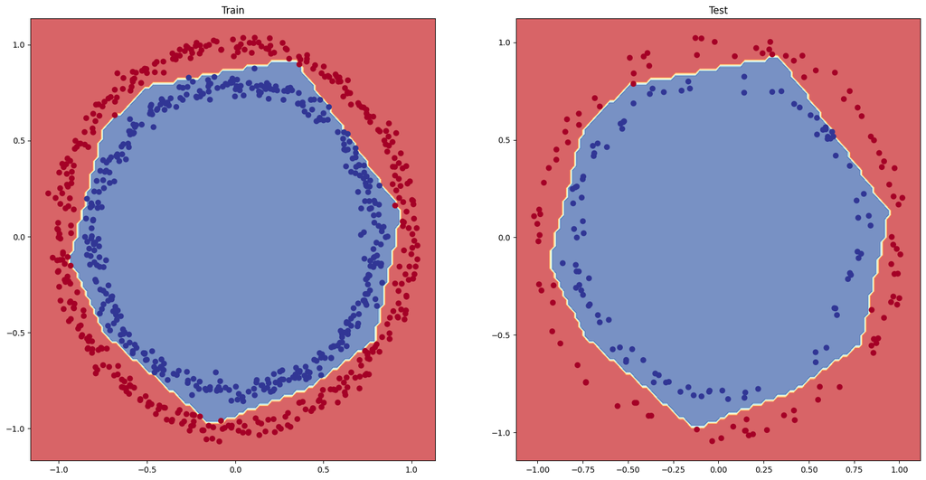

```python
# Plot the decision boundaries for the training and test sets
plt.figure(figsize=(20,10))
plt.subplot(1,2,1)
plt.title('Train')
plot_decision_boundary(model_8, X=X_train, y=y_train)
plt.subplot(1,2,2)
plt.title('Test')
plot_decision_boundary(model_8, X=X_test, y=y_test)
plt.show()
```

Hey, with a few tweaks, the model is now predicting the blue and red circles with near perfect accuracy!

### Plot the loss curves

With very good prediction by the model as above, how has the model down while it learnt?

We can check the **loss curves** (also referred to as the **learning cuves**).

We'll be using the variable `history` that we've seen on the `model.fit`. It keeps track on learning performance per epoch. And this is where we'll get the performance data.

```python
# you can access the info in history variable, by calling the .history attribute
pd.DataFrame(history.history)
```

|  | accuracy | loss |
| --- | --- | --- |
| 0 | 0.48875 | 0.694715 |
| 1 | 0.51875 | 0.686387 |
| 2 | 0.55750 | 0.680962 |
| 3 | 0.61250 | 0.673781 |
| 4 | 0.61375 | 0.663351 |
| ... | ... | ... |
| 95 | 0.98875 | 0.042589 |
| 96 | 0.98875 | 0.042117 |
| 97 | 0.99000 | 0.041604 |
| 98 | 0.98875 | 0.041303 |
| 99 | 0.99000 | 0.040779 |

100 rows × 2 columns

Inspecting the data, they accuracy increases as the loss decreases. How about in graph form?

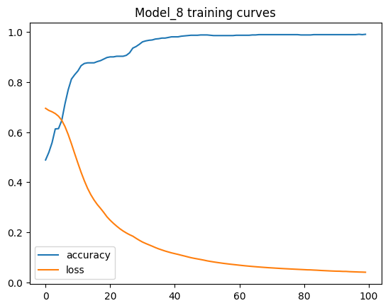

```python
# plot loss and accuracy graph
pd.DataFrame(history.history).plot()
plt.title('Model_8 training curves')
```

This is idealy what we'd like to see. Loss going down, accuracy going up. But we could've gotten away with stopping the training early by around 30ish epochs.

### Finding the best learning rate

Out of all hyperparameters, the most important is the **learning rate** of the neural network models.

Just decide to change something in it, and see what results come of it. With practice, you'll start to see what kind of parameters work or don't.

It's very experimental. You build the model, evaluate it, build it, and continue to evaluate it. But there is a trick to help you find the optimal learning rate (at least during the beginning of training).

To do so, we're going to use the following:

- [learning rate callback](https://www.tensorflow.org/api_docs/python/tf/keras/callbacks/LearningRateScheduler): Think of callback as extra piece of functionality you can add to your model while its training.
- Another model (could use the same above)
- A modified loss curves plot

> 💡**Note**: Default hyperparameters for most neural networks in TensorFlow, are setup to be able to work right out of the box. Where the parameters are tuned to be the best for the entire aggregate of possible problems. It's always a good idea to try the defaults first before adjusting.

```python
tf.random.set_seed(42)

model_9 = tf.keras.Sequential([
    tf.keras.layers.Dense(4, activation='relu'),
    tf.keras.layers.Dense(4, activation='relu'),
    tf.keras.layers.Dense(1, activation='sigmoid')
])

model_9.compile(loss='binary_crossentropy', # can use strings here too
                optimizer='Adam', # same to tf.keras.optimizers.Adam() with default settings
                metrics=['accuracy'])

lr_scheduler = tf.keras.callbacks.LearningRateScheduler(lambda epoch: 1e-4 * 10**(epoch/20)) # traverse a set of learning rate values starting from 1e-4, increasing by 10**(epoch/20) every epoch
                                                                                             # aka increasing learning rate on adam bit by bit per every epoch

# fit model and place lr_scheduler with callbacks
history = model_9.fit(X_train,
                      y_train,
                      epochs=100,
                      callbacks=[lr_scheduler])
```

```
25/25 ━━━━━━━━━━━━━━━━━━━━ 2s 3ms/step - accuracy: 0.4984 - loss: 0.7974 - learning_rate: 1.0000e-04
25/25 ━━━━━━━━━━━━━━━━━━━━ 0s 3ms/step - accuracy: 0.4984 - loss: 0.7941 - learning_rate: 1.1220e-04
25/25 ━━━━━━━━━━━━━━━━━━━━ 0s 3ms/step - accuracy: 0.4984 - loss: 0.7905 - learning_rate: 1.2589e-04
25/25 ━━━━━━━━━━━━━━━━━━━━ 0s 3ms/step - accuracy: 0.4984 - loss: 0.7867 - learning_rate: 1.4125e-04
25/25 ━━━━━━━━━━━━━━━━━━━━ 0s 4ms/step - accuracy: 0.4984 - loss: 0.7826 - learning_rate: 1.5849e-04
25/25 ━━━━━━━━━━━━━━━━━━━━ 0s 3ms/step - accuracy: 0.4984 - loss: 0.7784 - learning_rate: 1.7783e-04
25/25 ━━━━━━━━━━━━━━━━━━━━ 0s 3ms/step - accuracy: 0.4951 - loss: 0.7739 - learning_rate: 1.9953e-04
25/25 ━━━━━━━━━━━━━━━━━━━━ 0s 3ms/step - accuracy: 0.4939 - loss: 0.7693 - learning_rate: 2.2387e-04
25/25 ━━━━━━━━━━━━━━━━━━━━ 0s 3ms/step - accuracy: 0.4952 - loss: 0.7645 - learning_rate: 2.5119e-04
25/25 ━━━━━━━━━━━━━━━━━━━━ 0s 3ms/step - accuracy: 0.4934 - loss: 0.7596 - learning_rate: 2.8184e-04
25/25 ━━━━━━━━━━━━━━━━━━━━ 0s 3ms/step - accuracy: 0.4917 - loss: 0.7546 - learning_rate: 3.1623e-04
25/25 ━━━━━━━━━━━━━━━━━━━━ 0s 3ms/step - accuracy: 0.4845 - loss: 0.7497 - learning_rate: 3.5481e-04
25/25 ━━━━━━━━━━━━━━━━━━━━ 0s 4ms/step - accuracy: 0.4729 - loss: 0.7448 - learning_rate: 3.9811e-04
25/25 ━━━━━━━━━━━━━━━━━━━━ 0s 3ms/step - accuracy: 0.4763 - loss: 0.7400 - learning_rate: 4.4668e-04
25/25 ━━━━━━━━━━━━━━━━━━━━ 0s 3ms/step - accuracy: 0.4627 - loss: 0.7354 - learning_rate: 5.0119e-04
25/25 ━━━━━━━━━━━━━━━━━━━━ 0s 3ms/step - accuracy: 0.4559 - loss: 0.7310 - learning_rate: 5.6234e-04
25/25 ━━━━━━━━━━━━━━━━━━━━ 0s 3ms/step - accuracy: 0.4559 - loss: 0.7268 - learning_rate: 6.3096e-04
25/25 ━━━━━━━━━━━━━━━━━━━━ 0s 3ms/step - accuracy: 0.4726 - loss: 0.7228 - learning_rate: 7.0795e-04
25/25 ━━━━━━━━━━━━━━━━━━━━ 0s 3ms/step - accuracy: 0.4708 - loss: 0.7190 - learning_rate: 7.9433e-04
25/25 ━━━━━━━━━━━━━━━━━━━━ 0s 3ms/step - accuracy: 0.4645 - loss: 0.7156 - learning_rate: 8.9125e-04
25/25 ━━━━━━━━━━━━━━━━━━━━ 0s 4ms/step - accuracy: 0.4430 - loss: 0.7123 - learning_rate: 0.0010
25/25 ━━━━━━━━━━━━━━━━━━━━ 0s 3ms/step - accuracy: 0.4298 - loss: 0.7098 - learning_rate: 0.0011
25/25 ━━━━━━━━━━━━━━━━━━━━ 0s 3ms/step - accuracy: 0.4207 - loss: 0.7072 - learning_rate: 0.0013
25/25 ━━━━━━━━━━━━━━━━━━━━ 0s 3ms/step - accuracy: 0.4274 - loss: 0.7039 - learning_rate: 0.0014
25/25 ━━━━━━━━━━━━━━━━━━━━ 0s 3ms/step - accuracy: 0.3918 - loss: 0.7021 - learning_rate: 0.0016
25/25 ━━━━━━━━━━━━━━━━━━━━ 0s 4ms/step - accuracy: 0.4005 - loss: 0.7011 - learning_rate: 0.0018
25/25 ━━━━━━━━━━━━━━━━━━━━ 0s 4ms/step - accuracy: 0.4339 - loss: 0.7002 - learning_rate: 0.0020
25/25 ━━━━━━━━━━━━━━━━━━━━ 0s 4ms/step - accuracy: 0.4663 - loss: 0.6992 - learning_rate: 0.0022
25/25 ━━━━━━━━━━━━━━━━━━━━ 0s 3ms/step - accuracy: 0.4624 - loss: 0.6981 - learning_rate: 0.0025
25/25 ━━━━━━━━━━━━━━━━━━━━ 0s 3ms/step - accuracy: 0.4263 - loss: 0.6968 - learning_rate: 0.0028
25/25 ━━━━━━━━━━━━━━━━━━━━ 0s 3ms/step - accuracy: 0.4303 - loss: 0.6952 - learning_rate: 0.0032
25/25 ━━━━━━━━━━━━━━━━━━━━ 0s 3ms/step - accuracy: 0.4723 - loss: 0.6928 - learning_rate: 0.0035
25/25 ━━━━━━━━━━━━━━━━━━━━ 0s 3ms/step - accuracy: 0.5016 - loss: 0.6898 - learning_rate: 0.0040
25/25 ━━━━━━━━━━━━━━━━━━━━ 0s 3ms/step - accuracy: 0.5016 - loss: 0.6883 - learning_rate: 0.0045
25/25 ━━━━━━━━━━━━━━━━━━━━ 0s 3ms/step - accuracy: 0.4963 - loss: 0.6868 - learning_rate: 0.0050
25/25 ━━━━━━━━━━━━━━━━━━━━ 0s 4ms/step - accuracy: 0.5298 - loss: 0.6850 - learning_rate: 0.0056
25/25 ━━━━━━━━━━━━━━━━━━━━ 0s 3ms/step - accuracy: 0.5384 - loss: 0.6828 - learning_rate: 0.0063
25/25 ━━━━━━━━━━━━━━━━━━━━ 0s 3ms/step - accuracy: 0.5397 - loss: 0.6804 - learning_rate: 0.0071
25/25 ━━━━━━━━━━━━━━━━━━━━ 0s 4ms/step - accuracy: 0.5414 - loss: 0.6770 - learning_rate: 0.0079
25/25 ━━━━━━━━━━━━━━━━━━━━ 0s 4ms/step - accuracy: 0.5454 - loss: 0.6730 - learning_rate: 0.0089
```

[output cut: 45 more lines]

```
25/25 ━━━━━━━━━━━━━━━━━━━━ 0s 3ms/step - accuracy: 0.4885 - loss: 0.7233 - learning_rate: 1.7783
25/25 ━━━━━━━━━━━━━━━━━━━━ 0s 3ms/step - accuracy: 0.5006 - loss: 0.7364 - learning_rate: 1.9953
25/25 ━━━━━━━━━━━━━━━━━━━━ 0s 3ms/step - accuracy: 0.4883 - loss: 0.7509 - learning_rate: 2.2387
25/25 ━━━━━━━━━━━━━━━━━━━━ 0s 3ms/step - accuracy: 0.5051 - loss: 0.7587 - learning_rate: 2.5119
25/25 ━━━━━━━━━━━━━━━━━━━━ 0s 3ms/step - accuracy: 0.5045 - loss: 0.7419 - learning_rate: 2.8184
25/25 ━━━━━━━━━━━━━━━━━━━━ 0s 3ms/step - accuracy: 0.4949 - loss: 0.7106 - learning_rate: 3.1623
25/25 ━━━━━━━━━━━━━━━━━━━━ 0s 6ms/step - accuracy: 0.4824 - loss: 0.7116 - learning_rate: 3.5481
25/25 ━━━━━━━━━━━━━━━━━━━━ 0s 4ms/step - accuracy: 0.4798 - loss: 0.7163 - learning_rate: 3.9811
25/25 ━━━━━━━━━━━━━━━━━━━━ 0s 4ms/step - accuracy: 0.4732 - loss: 0.7238 - learning_rate: 4.4668
25/25 ━━━━━━━━━━━━━━━━━━━━ 0s 3ms/step - accuracy: 0.4732 - loss: 0.7430 - learning_rate: 5.0119
25/25 ━━━━━━━━━━━━━━━━━━━━ 0s 4ms/step - accuracy: 0.4849 - loss: 0.7811 - learning_rate: 5.6234
25/25 ━━━━━━━━━━━━━━━━━━━━ 0s 3ms/step - accuracy: 0.4844 - loss: 0.8226 - learning_rate: 6.3096
25/25 ━━━━━━━━━━━━━━━━━━━━ 0s 3ms/step - accuracy: 0.4892 - loss: 0.8662 - learning_rate: 7.0795
25/25 ━━━━━━━━━━━━━━━━━━━━ 0s 3ms/step - accuracy: 0.4892 - loss: 0.9091 - learning_rate: 7.9433
25/25 ━━━━━━━━━━━━━━━━━━━━ 0s 3ms/step - accuracy: 0.4892 - loss: 0.9533 - learning_rate: 8.9125
```

Our model has finished training, and let's have a look at training history.

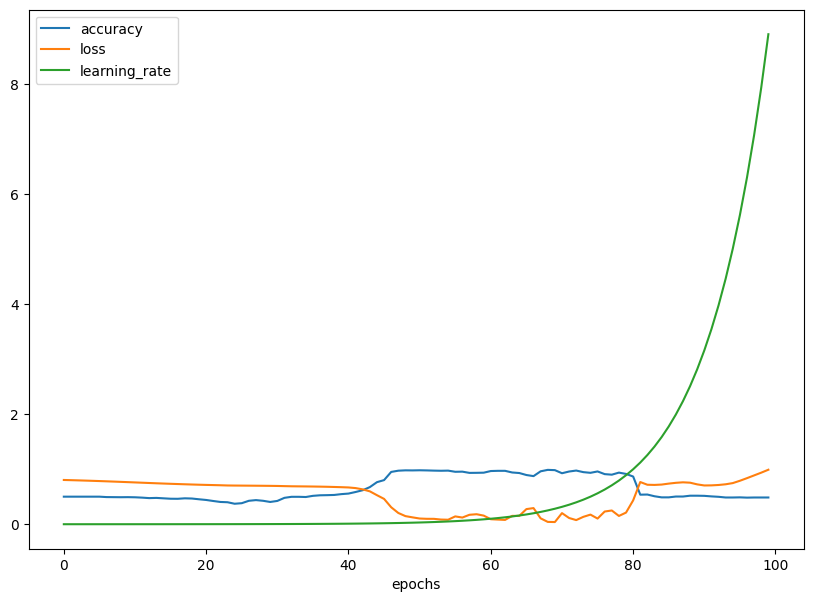

```python
# Checkout the history
pd.DataFrame(history.history).plot(figsize=(10,7), xlabel='epochs');
```

As the epoch increases, the learning rate exponentially increases.

You can see the model's accuracy going up and then down at specific point depending on the `learning_rate`.

We can figure this out and it's infliction point, by plotting the loss versus, log-scaled learning rate.

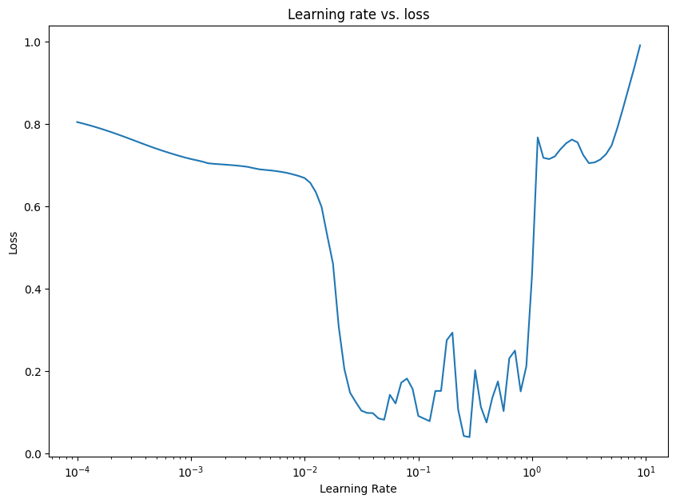

```python
# plot the learning rate versus the loss
lrs = 1e-4 * (10 ** (np.arange(100)/20)) # recreate learning rate rule for x-axis
plt.figure(figsize=(10,7))
plt.semilogx(lrs,history.history['loss']) # we want the x-axis (learning rate) to be log scale as to be plotted without heavy skewing (keeping it linear)
plt.xlabel('Learning Rate')
plt.ylabel('Loss')
plt.title('Learning rate vs. loss');
```

A good rule of thumb when picking the learning rate, is where the loss is decreasing but hasn't fully flattened out. That ends up to be around 0.03 to 0.04 for us.

Now we've got our answer to ideal learning rate, let's implement it in model.

```python
tf.random.set_seed(42)

model_10 = tf.keras.Sequential([
    tf.keras.layers.Dense(4, activation='relu'),
    tf.keras.layers.Dense(4, activation='relu'),
    tf.keras.layers.Dense(1, activation='sigmoid')
])

model_10.compile(loss='binary_crossentropy',
                 optimizer=tf.keras.optimizers.Adam(learning_rate=0.04), # must use tf.keras to change Adams learning rate
                 metrics=['accuracy'])

history = model_10.fit(X_train, y_train, epochs=20)
```

```
25/25 ━━━━━━━━━━━━━━━━━━━━ 2s 4ms/step - accuracy: 0.5138 - loss: 0.6987
25/25 ━━━━━━━━━━━━━━━━━━━━ 0s 3ms/step - accuracy: 0.5367 - loss: 0.6879
25/25 ━━━━━━━━━━━━━━━━━━━━ 0s 4ms/step - accuracy: 0.5441 - loss: 0.6848
25/25 ━━━━━━━━━━━━━━━━━━━━ 0s 3ms/step - accuracy: 0.5519 - loss: 0.6731
25/25 ━━━━━━━━━━━━━━━━━━━━ 0s 3ms/step - accuracy: 0.6351 - loss: 0.6307
25/25 ━━━━━━━━━━━━━━━━━━━━ 0s 3ms/step - accuracy: 0.6976 - loss: 0.5699
25/25 ━━━━━━━━━━━━━━━━━━━━ 0s 4ms/step - accuracy: 0.7652 - loss: 0.4969
25/25 ━━━━━━━━━━━━━━━━━━━━ 0s 4ms/step - accuracy: 0.7911 - loss: 0.4601
25/25 ━━━━━━━━━━━━━━━━━━━━ 0s 4ms/step - accuracy: 0.8059 - loss: 0.4257
25/25 ━━━━━━━━━━━━━━━━━━━━ 0s 3ms/step - accuracy: 0.8170 - loss: 0.4065
25/25 ━━━━━━━━━━━━━━━━━━━━ 0s 3ms/step - accuracy: 0.8443 - loss: 0.3820
25/25 ━━━━━━━━━━━━━━━━━━━━ 0s 3ms/step - accuracy: 0.8513 - loss: 0.3689
25/25 ━━━━━━━━━━━━━━━━━━━━ 0s 4ms/step - accuracy: 0.8567 - loss: 0.3630
25/25 ━━━━━━━━━━━━━━━━━━━━ 0s 3ms/step - accuracy: 0.8660 - loss: 0.3395
25/25 ━━━━━━━━━━━━━━━━━━━━ 0s 3ms/step - accuracy: 0.8666 - loss: 0.3385
25/25 ━━━━━━━━━━━━━━━━━━━━ 0s 4ms/step - accuracy: 0.8746 - loss: 0.3168
25/25 ━━━━━━━━━━━━━━━━━━━━ 0s 4ms/step - accuracy: 0.8922 - loss: 0.2970
25/25 ━━━━━━━━━━━━━━━━━━━━ 0s 4ms/step - accuracy: 0.9020 - loss: 0.2699
25/25 ━━━━━━━━━━━━━━━━━━━━ 0s 3ms/step - accuracy: 0.9356 - loss: 0.2101
25/25 ━━━━━━━━━━━━━━━━━━━━ 0s 3ms/step - accuracy: 0.9810 - loss: 0.0848
```

```python
# evaluate model on the test dataset
model_10.evaluate(X_test, y_test)
```

```
7/7 ━━━━━━━━━━━━━━━━━━━━ 0s 7ms/step - accuracy: 0.9759 - loss: 0.1018
```

```
[0.10529811680316925, 0.9649999737739563]
```

Let's see how the predictions look in graph form.

```
313/313 ━━━━━━━━━━━━━━━━━━━━ 1s 2ms/step
doing binary classification...
313/313 ━━━━━━━━━━━━━━━━━━━━ 1s 2ms/step
doing binary classification...
```

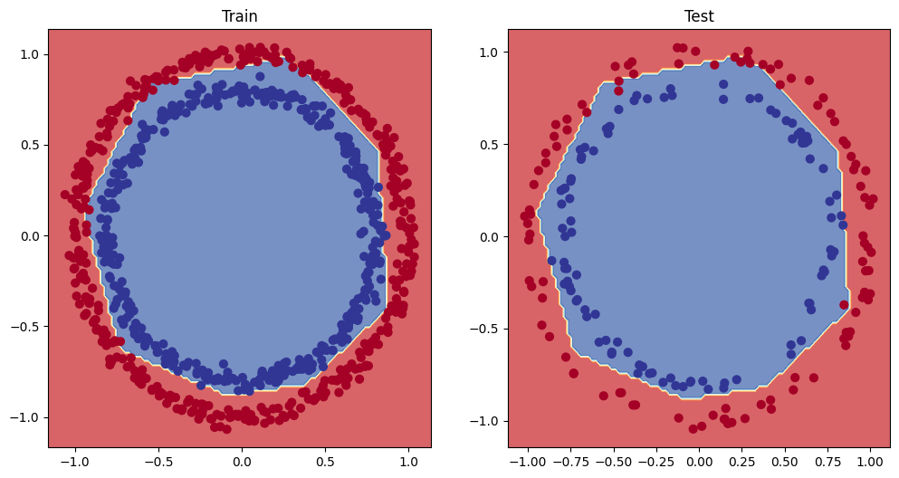

```python
plt.figure(figsize=(12,6))
plt.subplot(1,2,1)
plt.title('Train')
plot_decision_boundary(model_10, X=X_train, y=y_train)
plt.subplot(1,2,2)
plt.title('Test')
plot_decision_boundary(model_10, X=X_test, y=y_test)
plt.show()
```

Almost perfect like the previous.

These are the kind of experiments you'll run when building models. Start with default settings, see how they work. If they don't perform well, improve on them.

#### More classification evaluation methods

Along with the visuals we make, there are a number of different evaluation metrics to use on our classification models.

[output not shown]

> 💡 **Note**: Every classification problem will require diferent evaluation methods. At least be familiar with the main ones above! ^

Let's start with accuracy.

Luckily we've already have `accuracy` in our evaluation function.

```python
# check model accuracy
loss, accuracy = model_10.evaluate(X_test, y_test)
print(f'Model loss on test set: {loss}')
print(f'Model accuracy on test set: {(accuracy*100):.2f}%')
```

```
7/7 ━━━━━━━━━━━━━━━━━━━━ 0s 8ms/step - accuracy: 0.9759 - loss: 0.1018
Model loss on test set: 0.10529811680316925
Model accuracy on test set: 96.50%
```

What about confusion matrix?

We can make it using Scikit-Learn's `confusion_matrix` method.

```python
# create a confusion matrix
from sklearn.metrics import confusion_matrix

# make predictions
y_preds = model_10.predict(X_test)

# create confusion matrix
confusion_matrix(y_test, y_preds)
```

```
7/7 ━━━━━━━━━━━━━━━━━━━━ 0s 6ms/step
```

[output not shown]

Seems like our predictions aren't formatted correctly.

Let's check the issue.

```python
# View the first 10 predictions
y_preds[:10]
```

```
array([[0.9500701 ],
       [0.9500701 ],
       [0.9500701 ],
       [0.9500701 ],
       [0.3598913 ],
       [0.13977087],
       [0.9500701 ],
       [0.05345658],
       [0.9461679 ],
       [0.05158524]], dtype=float32)
```

And our test labels?

```python
# View the first 10 test labels
y_test[:10]
```

```
array([1, 1, 1, 1, 0, 0, 1, 0, 1, 0])
```

Looks like our predictions are in **prediction probabilities**, rather than the test format of **binary**.

You'll see this often with outputs of neural networks. Often won't be exact values, but more a probability of how *likey* they are to be one thing or another.

So a common step you'll see, is converting the predictions into binary labels. We can do this by converting prediction probabilities to their binary form with `tf.round()`.

```python
# Convert prediction probabilities to binary format and view the first 10
tf.round(y_preds)[:10]
```

```
<tf.Tensor: shape=(10, 1), dtype=float32, numpy=
array([[1.],
       [1.],
       [1.],
       [1.],
       [0.],
       [0.],
       [1.],
       [0.],
       [1.],
       [0.]], dtype=float32)>
```

Sweet! Now we can use the `confusion_matrix` function :)

```python
# create a confusion matrix
confusion_matrix(y_test, tf.round(y_preds)) # round values in prediction, so it becomes binary, rather than floats
```

```
array([[94,  7],
       [ 0, 99]])
```

We can see the highest values are diagonally displayed from top left, to bottom right. Which is a good sign for accuracy of model. But it's a bit difficult to tell from its simplicity.

How about we make a function to make our confusion matrix more visual and nice to look at?

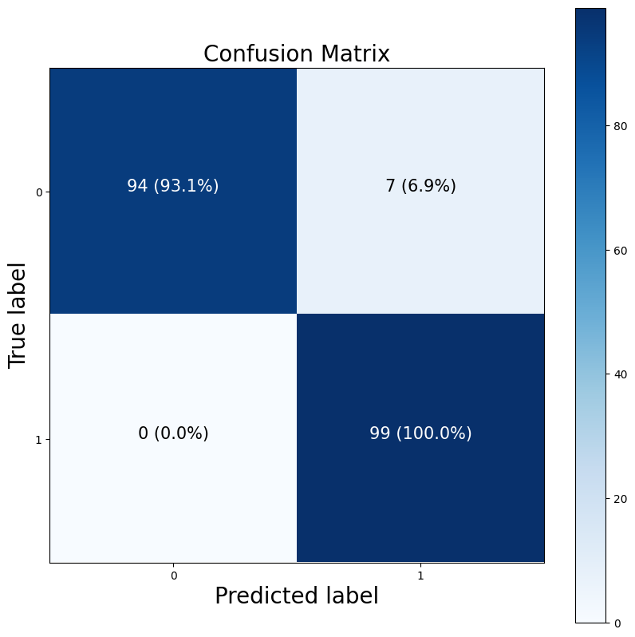

```python
# Note: The following confusion matrix code is a remix of Scikit-Learn's 'plot_confusion_matrix', and made with ML's introductory notebook https://github.com/GokuMohandas/MadeWithML/blob/main/notebooks/08_Neural_Networks.ipynb
import itertools

figsize = (10,10)

# create the confusion matrix
cm = confusion_matrix(y_test, tf.round(y_preds))
cm_norm = cm.astype('float') / cm.sum(axis=1)[:, np.newaxis] # normalizing, 'float' > we'll be dividing, 'cm.sum' to count all values of truth labels and dividing it everytime with each prediction, false or negative
                                                             # aka, this is a percentage calculator, calculating how many percent of the prediction was in 1, in 0, or at another 3rd label.
n_classes = cm.shape[0] # extract true values from column 0

# Let's prettify it
fig, ax = plt.subplots(figsize=figsize)
# create a matrix plot
cax = ax.matshow(cm, cmap=plt.cm.Blues) # https://matplotlib.org/3.2.0/api/_as_gen/matplotlib.axes.Axes.matshow.html
                                        # matshow > heatmap for our confusion matrix, cmap > to colour our graph with blue to visually represent values on heatmap
                                        # saving it as variable for later modification
fig.colorbar(cax) # add colourbar to reference against the values

# create classes to identify between true values and prediction
classes = False

if classes:
    labels = classes
else:
    labels = np.arange(cm.shape[0])

# label the axes
ax.set(title='Confusion Matrix',
       xlabel='Predicted label',
       ylabel='True label',
       xticks=np.arange(n_classes), # specifying placement of ticks. Ticks are like placeholder of major points/value to the graph, aka the labels that goes on the graph.
       yticks=np.arange(n_classes),
       xticklabels=labels,
       yticklabels=labels)

# Set x-axis labels to bottom
ax.xaxis.set_label_position('bottom')
ax.xaxis.tick_bottom()

# Adjust label size
ax.xaxis.label.set_size(20)
ax.yaxis.label.set_size(20)
ax.title.set_size(20)

# set threshold for diferent colours
threshold = (cm.max() + cm.min()) / 2. # find the midpoint value between min and max. Helps with colouring text annotations, when choosing black, or white, based on the supposed contrast of the colour at the back.

# plot the text on each cell, looping until all text is added
for i, j in itertools.product(range(cm.shape[0]), range(cm.shape[1])): # i and j, representing true and predicted values respectively
    plt.text(j, i, f'{cm[i, j]} ({cm_norm[i, j]*100:.1f}%)', # format them into percentage of output. Aka out of all 1s that are true, how many are predicted as 1, or 0 as a percentage?
             horizontalalignment='center', # centers text inside the cell
             color='white' if cm[i, j] > threshold else 'black', # text colour based on the contrast of the cell at the back. Done by seeing whether its at the upper half or lower half of values.
             size=15)
```

```python
# what does itertools.product do? combines two things into each combination
import itertools
for i, j in itertools.product(range(cm.shape[0]), range(cm.shape[1])):
    print(i,j)
```

```
0 0
0 1
1 0
1 1
```

### Working with a larger example (multiclass classification)

We've seen a binary classificaion example (our prediction of the blue and red circle), but what if you had multiple different classes of things?

Say, you were a fashion company and wanted to build a neural network to predict whether a piece of clothing is a shoe, a shirt, or a jacket (3 different options).

When you have more than two classes as an option, this is known as **multiclass classification**.

Good news is, the things we've learnt so far can be applied to multiclass classification problems as well.

Let's see it in action.

To start, we need data. And we have one as [Fashion MNIST built-in](https://github.com/zalandoresearch/fashion-mnist). Meaning we can get started straight away.

We can import it using `tf.keras.datasets` module.

> 📖**Resource**: The following multiclass classification problem has been afapted from the [TensorFlow classification guide](https://www.tensorflow.org/tutorials/keras/classification). A good exercise would be to replicate the TensorFlow guide after following through the examples here.

```python
import tensorflow as tf
from tensorflow.keras.datasets import fashion_mnist

# the data has already been sorted into training and test sets for us
(train_data, train_labels), (test_data, test_labels) = fashion_mnist.load_data()
```

Now let's check out an example.

```python
# show the first training example
print(f'Training sample:\n{train_data[0]}\n')
print(f'Traininglabel: {train_labels[0]}')
```

```
Training sample:
[[  0   0   0   0   0   0   0   0   0   0   0   0   0   0   0   0   0   0
    0   0   0   0   0   0   0   0   0   0]
 [  0   0   0   0   0   0   0   0   0   0   0   0   0   0   0   0   0   0
    0   0   0   0   0   0   0   0   0   0]
 [  0   0   0   0   0   0   0   0   0   0   0   0   0   0   0   0   0   0
    0   0   0   0   0   0   0   0   0   0]
 [  0   0   0   0   0   0   0   0   0   0   0   0   1   0   0  13  73   0
    0   1   4   0   0   0   0   1   1   0]
 [  0   0   0   0   0   0   0   0   0   0   0   0   3   0  36 136 127  62
   54   0   0   0   1   3   4   0   0   3]
 [  0   0   0   0   0   0   0   0   0   0   0   0   6   0 102 204 176 134
  144 123  23   0   0   0   0  12  10   0]
 [  0   0   0   0   0   0   0   0   0   0   0   0   0   0 155 236 207 178
  107 156 161 109  64  23  77 130  72  15]
 [  0   0   0   0   0   0   0   0   0   0   0   1   0  69 207 223 218 216
  216 163 127 121 122 146 141  88 172  66]
 [  0   0   0   0   0   0   0   0   0   1   1   1   0 200 232 232 233 229
  223 223 215 213 164 127 123 196 229   0]
 [  0   0   0   0   0   0   0   0   0   0   0   0   0 183 225 216 223 228
  235 227 224 222 224 221 223 245 173   0]
 [  0   0   0   0   0   0   0   0   0   0   0   0   0 193 228 218 213 198
  180 212 210 211 213 223 220 243 202   0]
 [  0   0   0   0   0   0   0   0   0   1   3   0  12 219 220 212 218 192
  169 227 208 218 224 212 226 197 209  52]
 [  0   0   0   0   0   0   0   0   0   0   6   0  99 244 222 220 218 203
  198 221 215 213 222 220 245 119 167  56]
 [  0   0   0   0   0   0   0   0   0   4   0   0  55 236 228 230 228 240
  232 213 218 223 234 217 217 209  92   0]
 [  0   0   1   4   6   7   2   0   0   0   0   0 237 226 217 223 222 219
  222 221 216 223 229 215 218 255  77   0]
 [  0   3   0   0   0   0   0   0   0  62 145 204 228 207 213 221 218 208
  211 218 224 223 219 215 224 244 159   0]
 [  0   0   0   0  18  44  82 107 189 228 220 222 217 226 200 205 211 230
  224 234 176 188 250 248 233 238 215   0]
 [  0  57 187 208 224 221 224 208 204 214 208 209 200 159 245 193 206 223
  255 255 221 234 221 211 220 232 246   0]
 [  3 202 228 224 221 211 211 214 205 205 205 220 240  80 150 255 229 221
  188 154 191 210 204 209 222 228 225   0]
 [ 98 233 198 210 222 229 229 234 249 220 194 215 217 241  65  73 106 117
  168 219 221 215 217 223 223 224 229  29]
 [ 75 204 212 204 193 205 211 225 216 185 197 206 198 213 240 195 227 245
  239 223 218 212 209 222 220 221 230  67]
 [ 48 203 183 194 213 197 185 190 194 192 202 214 219 221 220 236 225 216
  199 206 186 181 177 172 181 205 206 115]
 [  0 122 219 193 179 171 183 196 204 210 213 207 211 210 200 196 194 191
  195 191 198 192 176 156 167 177 210  92]
 [  0   0  74 189 212 191 175 172 175 181 185 188 189 188 193 198 204 209
  210 210 211 188 188 194 192 216 170   0]
 [  2   0   0   0  66 200 222 237 239 242 246 243 244 221 220 193 191 179
  182 182 181 176 166 168  99  58   0   0]
 [  0   0   0   0   0   0   0  40  61  44  72  41  35   0   0   0   0   0
    0   0   0   0   0   0   0   0   0   0]
 [  0   0   0   0   0   0   0   0   0   0   0   0   0   0   0   0   0   0
    0   0   0   0   0   0   0   0   0   0]
 [  0   0   0   0   0   0   0   0   0   0   0   0   0   0   0   0   0   0
    0   0   0   0   0   0   0   0   0   0]]

Traininglabel: 9
```

Interesting, we get a large list of numbers, organized n columns and then a training label value. How about the shape?

```python
# check the shape of our data
train_data.shape, train_labels.shape, test_data.shape, test_labels.shape
```

```
((60000, 28, 28), (60000,), (10000, 28, 28), (10000,))
```

```python
# check a single sample
train_data[0].shape, train_labels[0].shape
```

```
((28, 28), ())
```

Okay so there are 60,000 training examples with the shape of `28, 28` with labels on each of them, as well as 10,000 test examples in the same shape. It's hard to picture in numbers, so we'll viualize it.

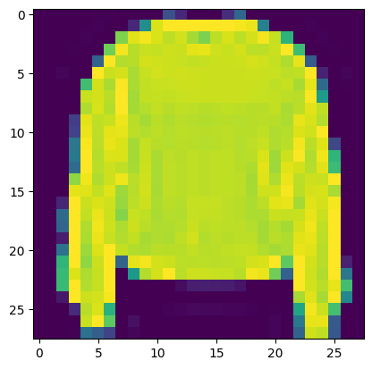

```python
# plot a single example
import matplotlib.pyplot as plt
plt.imshow(train_data[7]);
```

And how about it's label?

```python
train_labels[7]
```

```
np.uint8(2)
```

Looks like our labels are numerical. This may be fine for neural networks, but you might want to have it in a human readable format.

Let's create a small list of the class names (we can find them on the dataset's github page).

> 📝**Note**: It's important to note how the dataset here is ready to go into model building, most if not all real world problems are not like this. Often you'll have to do a few preprocessing steps to have it ready for a neural network.

```python
class_names = ['T-shirt/top','Trouse','Pullover','Dress','Coat','Sandal','Shirt','Sneaker','Bag','Ankle boot']

# how many classes are there (this'll be our output shape)
len(class_names)
```

```
10
```

Let's plot another example

> 🤔**Question**: Pay attention to what the data we're working with *looks* like. Is it straight lines, or non-linear? Do you thin the patterns found in these clothes pictures neg non-linearity for the model to perform at its optimum?

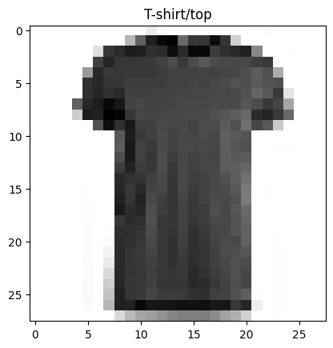

```python
# plot an example image and its label
plt.imshow(train_data[17], cmap=plt.cm.binary) # change the colours to black and white
plt.title(class_names[train_labels[17]]);
```

[figure not shown]

```python
# plot multiple random images of fashion MNIST
import random # randomizer for import of random images
plt.figure(figsize=(7,7))
for i in range(4): # for loop repeat 4 times
    ax = plt.subplot(2,2,i+1) # 2 by 2 plot, increasing by 1
    rand_index = random.choice(range(len(train_data))) # choosing random images from the random generated values out of the length of the dataset
    plt.imshow(train_data[rand_index], cmap=plt.cm.binary) # train_data[rand_index] > pulling train data from random index, colouring map is binary, aka black and white
    plt.title(class_names[train_labels[rand_index]]) # add title, and the labels of each random images added to the plot
    plt.axis(False) # no axis
```

Let's build a model to figure out the relationship between te pixel values and their labels.

We'll need to make a few changes to our architecture, from binary classification to multiclass classification:

```python
# set random seed
tf.random.set_seed(42)

# create the model
model_11 = tf.keras.Sequential([
    tf.keras.layers.Flatten(input_shape=(28,28)), # input layer (have to reshape 28x28 to 784, flatten layer does this for us)
    tf.keras.layers.Dense(4, activation='relu'),
    tf.keras.layers.Dense(4, activation='relu'),
    tf.keras.layers.Dense(10, activation='softmax') # output shape is 10, activation is softmax
])

# compile the model
model_11.compile(loss=tf.keras.losses.SparseCategoricalCrossentropy(), # different loss function for multiclass classification
                 optimizer=tf.keras.optimizers.Adam(),
                 metrics=['accuracy'])

# fit the model
non_norm_history = model_11.fit(train_data,
                                train_labels,
                                epochs=10,
                                validation_data=(test_data, test_labels)) # see how the model performs on the test set during training
```

```
1875/1875 ━━━━━━━━━━━━━━━━━━━━ 11s 5ms/step - accuracy: 0.1951 - loss: 2.1787 - val_accuracy: 0.2850 - val_loss: 1.7527
1875/1875 ━━━━━━━━━━━━━━━━━━━━ 7s 3ms/step - accuracy: 0.2845 - loss: 1.7026 - val_accuracy: 0.3266 - val_loss: 1.5927
1875/1875 ━━━━━━━━━━━━━━━━━━━━ 5s 3ms/step - accuracy: 0.3536 - loss: 1.5569 - val_accuracy: 0.3516 - val_loss: 1.4872
1875/1875 ━━━━━━━━━━━━━━━━━━━━ 10s 5ms/step - accuracy: 0.3710 - loss: 1.4801 - val_accuracy: 0.3517 - val_loss: 1.4580
1875/1875 ━━━━━━━━━━━━━━━━━━━━ 7s 4ms/step - accuracy: 0.3741 - loss: 1.4499 - val_accuracy: 0.3500 - val_loss: 1.4460
1875/1875 ━━━━━━━━━━━━━━━━━━━━ 7s 4ms/step - accuracy: 0.3751 - loss: 1.4312 - val_accuracy: 0.3509 - val_loss: 1.4370
1875/1875 ━━━━━━━━━━━━━━━━━━━━ 5s 3ms/step - accuracy: 0.3766 - loss: 1.4192 - val_accuracy: 0.3491 - val_loss: 1.4351
1875/1875 ━━━━━━━━━━━━━━━━━━━━ 5s 3ms/step - accuracy: 0.3784 - loss: 1.4108 - val_accuracy: 0.3633 - val_loss: 1.4147
1875/1875 ━━━━━━━━━━━━━━━━━━━━ 5s 3ms/step - accuracy: 0.3785 - loss: 1.4046 - val_accuracy: 0.3648 - val_loss: 1.4091
1875/1875 ━━━━━━━━━━━━━━━━━━━━ 5s 3ms/step - accuracy: 0.3790 - loss: 1.3992 - val_accuracy: 0.3647 - val_loss: 1.4095
```

```python
# check the shapes of our model
# note: the 'none' in (none, 784) is for batch_size, we'll cover this in a later module
model_11.summary()
```

```
Model: "sequential_11"
```

```
┏━━━━━━━━━━━━━━━━━━━━━━━━━━━━━━━━━┳━━━━━━━━━━━━━━━━━━━━━━━━┳━━━━━━━━━━━━━━━┓
┃ Layer (type)                    ┃ Output Shape           ┃       Param # ┃
┡━━━━━━━━━━━━━━━━━━━━━━━━━━━━━━━━━╇━━━━━━━━━━━━━━━━━━━━━━━━╇━━━━━━━━━━━━━━━┩
│ flatten (Flatten)               │ (None, 784)            │             0 │
├─────────────────────────────────┼────────────────────────┼───────────────┤
│ dense_28 (Dense)                │ (None, 4)              │         3,140 │
├─────────────────────────────────┼────────────────────────┼───────────────┤
│ dense_29 (Dense)                │ (None, 4)              │            20 │
├─────────────────────────────────┼────────────────────────┼───────────────┤
│ dense_30 (Dense)                │ (None, 10)             │            50 │
└─────────────────────────────────┴────────────────────────┴───────────────┘
```

```
 Total params: 9,632 (37.63 KB)
```

```
 Trainable params: 3,210 (12.54 KB)
```

```
 Non-trainable params: 0 (0.00 B)
```

```
 Optimizer params: 6,422 (25.09 KB)
```

Remember neural networks prefer numbers between 0 to 1? Our multiclass problem here has not been normalized yet. As the pixel values are between 0 to 255.

Let's see.

```python
# check the min and max values of training data
train_data.min(), train_data.max()
```

```
(np.uint8(0), np.uint8(255))
```

We can get these values between 0 and 1 by dividing all values by 255, successcully normalizing it.

```python
# divide train and test images by max value (normalize it)
train_data = train_data/255.0
test_data = test_data/255.0

# check the min mac values of the training data
train_data.min(), test_data.max()
```

```
(np.float64(0.0), np.float64(1.0))
```

Now our data is between 0 and 1, let's see what happens with the model. We'll use the same model as before (`model_11`) except with the normalized data.

```python
tf.random.set_seed(42)

model_12=tf.keras.Sequential([
    tf.keras.layers.Flatten(input_shape=(28,28)),
    tf.keras.layers.Dense(4,activation='relu'),
    tf.keras.layers.Dense(4,activation='relu'),
    tf.keras.layers.Dense(10,activation='softmax')
])

model_12.compile(loss=tf.keras.losses.SparseCategoricalCrossentropy(),
                 optimizer=tf.keras.optimizers.Adam(),
                 metrics=['accuracy'])

norm_history=model_12.fit(train_data,
                          train_labels,
                          epochs=10,
                          validation_data=(test_data,test_labels))
```

```
1875/1875 ━━━━━━━━━━━━━━━━━━━━ 7s 3ms/step - accuracy: 0.2820 - loss: 1.8219 - val_accuracy: 0.6107 - val_loss: 0.9025
1875/1875 ━━━━━━━━━━━━━━━━━━━━ 5s 3ms/step - accuracy: 0.6680 - loss: 0.8318 - val_accuracy: 0.7508 - val_loss: 0.7084
1875/1875 ━━━━━━━━━━━━━━━━━━━━ 5s 3ms/step - accuracy: 0.7581 - loss: 0.6804 - val_accuracy: 0.7785 - val_loss: 0.6560
1875/1875 ━━━━━━━━━━━━━━━━━━━━ 6s 3ms/step - accuracy: 0.7827 - loss: 0.6327 - val_accuracy: 0.7901 - val_loss: 0.6314
1875/1875 ━━━━━━━━━━━━━━━━━━━━ 5s 3ms/step - accuracy: 0.7929 - loss: 0.6066 - val_accuracy: 0.7953 - val_loss: 0.6161
1875/1875 ━━━━━━━━━━━━━━━━━━━━ 5s 3ms/step - accuracy: 0.7992 - loss: 0.5899 - val_accuracy: 0.7996 - val_loss: 0.6055
1875/1875 ━━━━━━━━━━━━━━━━━━━━ 5s 3ms/step - accuracy: 0.8036 - loss: 0.5778 - val_accuracy: 0.8010 - val_loss: 0.5984
1875/1875 ━━━━━━━━━━━━━━━━━━━━ 5s 2ms/step - accuracy: 0.8054 - loss: 0.5686 - val_accuracy: 0.8044 - val_loss: 0.5919
1875/1875 ━━━━━━━━━━━━━━━━━━━━ 5s 2ms/step - accuracy: 0.8084 - loss: 0.5614 - val_accuracy: 0.8042 - val_loss: 0.5879
1875/1875 ━━━━━━━━━━━━━━━━━━━━ 5s 3ms/step - accuracy: 0.8104 - loss: 0.5555 - val_accuracy: 0.8055 - val_loss: 0.5845
```

Wow, with the same model except normalized data, we see a much higher accuracy value!

Let's plot each model's history (their loss curve).

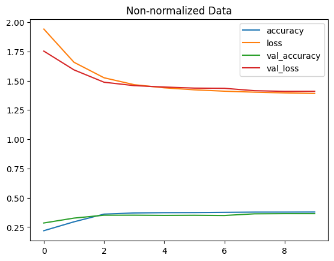

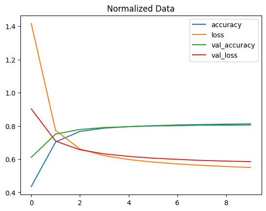

```python
import pandas as pd
# plot non-normalized data loss curves
pd.DataFrame(non_norm_history.history).plot(title='Non-normalized Data')
# plot normalized data loss curves
pd.DataFrame(norm_history.history).plot(title='Normalized Data');
```

From the plots, we can see how our model with normalized data (`model_12`) improved more than non-normalized (`model_11`).

> 💡 **Note**: Same models with even *slightly* different data, can produce *dramatically* different results. So when comparing models, make sure you compare them to the same criteras, such as same architecture but diferent data, same data but different architecture. Aka any changes you make should be limited to one source, as it'll give you an idea on what part of the model help improve it or not.

What about the ideal learning rate and see what happens?

We'll use the same architevure we've been using.

```python
tf.random.set_seed(42)

model_13=tf.keras.Sequential([
    tf.keras.layers.Flatten(input_shape=(28,28)),
    tf.keras.layers.Dense(4,activation='relu'),
    tf.keras.layers.Dense(4,activation='relu'),
    tf.keras.layers.Dense(10,activation='softmax')
])

model_13.compile(loss=tf.keras.losses.SparseCategoricalCrossentropy(),
                 optimizer=tf.keras.optimizers.Adam(),
                 metrics=['accuracy'])

# create the learning rate callback
lr_scheduler=tf.keras.callbacks.LearningRateScheduler(lambda epoch: 1e-3 * 10 ** (epoch/20)) # updating learning rate by the prescribed mathematical operation in the brackets. Increasing explonentially

find_lr_history=model_13.fit(train_data,
                             train_labels,
                             epochs=40, # model is already doing pretty good, so no need for high epochs like 100
                             validation_data=(test_data,test_labels),
                             callbacks=[lr_scheduler])
```

```
1875/1875 ━━━━━━━━━━━━━━━━━━━━ 9s 4ms/step - accuracy: 0.2285 - loss: 1.9217 - val_accuracy: 0.5915 - val_loss: 1.0734 - learning_rate: 0.0010
1875/1875 ━━━━━━━━━━━━━━━━━━━━ 7s 4ms/step - accuracy: 0.6095 - loss: 1.0263 - val_accuracy: 0.6713 - val_loss: 0.9251 - learning_rate: 0.0011
1875/1875 ━━━━━━━━━━━━━━━━━━━━ 10s 5ms/step - accuracy: 0.6778 - loss: 0.8998 - val_accuracy: 0.6932 - val_loss: 0.8693 - learning_rate: 0.0013
1875/1875 ━━━━━━━━━━━━━━━━━━━━ 8s 4ms/step - accuracy: 0.7065 - loss: 0.8443 - val_accuracy: 0.6992 - val_loss: 0.8401 - learning_rate: 0.0014
1875/1875 ━━━━━━━━━━━━━━━━━━━━ 7s 4ms/step - accuracy: 0.7186 - loss: 0.8114 - val_accuracy: 0.7155 - val_loss: 0.8136 - learning_rate: 0.0016
1875/1875 ━━━━━━━━━━━━━━━━━━━━ 7s 4ms/step - accuracy: 0.7285 - loss: 0.7902 - val_accuracy: 0.7272 - val_loss: 0.7935 - learning_rate: 0.0018
1875/1875 ━━━━━━━━━━━━━━━━━━━━ 7s 4ms/step - accuracy: 0.7337 - loss: 0.7765 - val_accuracy: 0.7338 - val_loss: 0.7810 - learning_rate: 0.0020
1875/1875 ━━━━━━━━━━━━━━━━━━━━ 5s 3ms/step - accuracy: 0.7386 - loss: 0.7666 - val_accuracy: 0.7392 - val_loss: 0.7733 - learning_rate: 0.0022
1875/1875 ━━━━━━━━━━━━━━━━━━━━ 6s 3ms/step - accuracy: 0.7404 - loss: 0.7593 - val_accuracy: 0.7398 - val_loss: 0.7689 - learning_rate: 0.0025
1875/1875 ━━━━━━━━━━━━━━━━━━━━ 5s 3ms/step - accuracy: 0.7414 - loss: 0.7534 - val_accuracy: 0.7406 - val_loss: 0.7652 - learning_rate: 0.0028
1875/1875 ━━━━━━━━━━━━━━━━━━━━ 5s 3ms/step - accuracy: 0.7426 - loss: 0.7484 - val_accuracy: 0.7402 - val_loss: 0.7627 - learning_rate: 0.0032
1875/1875 ━━━━━━━━━━━━━━━━━━━━ 6s 3ms/step - accuracy: 0.7426 - loss: 0.7433 - val_accuracy: 0.7392 - val_loss: 0.7605 - learning_rate: 0.0035
1875/1875 ━━━━━━━━━━━━━━━━━━━━ 5s 3ms/step - accuracy: 0.7433 - loss: 0.7350 - val_accuracy: 0.7354 - val_loss: 0.7640 - learning_rate: 0.0040
1875/1875 ━━━━━━━━━━━━━━━━━━━━ 6s 3ms/step - accuracy: 0.7474 - loss: 0.7203 - val_accuracy: 0.7427 - val_loss: 0.7434 - learning_rate: 0.0045
1875/1875 ━━━━━━━━━━━━━━━━━━━━ 5s 3ms/step - accuracy: 0.7506 - loss: 0.7062 - val_accuracy: 0.7489 - val_loss: 0.7244 - learning_rate: 0.0050
1875/1875 ━━━━━━━━━━━━━━━━━━━━ 5s 3ms/step - accuracy: 0.7531 - loss: 0.6967 - val_accuracy: 0.7521 - val_loss: 0.7106 - learning_rate: 0.0056
1875/1875 ━━━━━━━━━━━━━━━━━━━━ 5s 3ms/step - accuracy: 0.7539 - loss: 0.6879 - val_accuracy: 0.7548 - val_loss: 0.7040 - learning_rate: 0.0063
1875/1875 ━━━━━━━━━━━━━━━━━━━━ 6s 3ms/step - accuracy: 0.7554 - loss: 0.6832 - val_accuracy: 0.7539 - val_loss: 0.7024 - learning_rate: 0.0071
1875/1875 ━━━━━━━━━━━━━━━━━━━━ 10s 5ms/step - accuracy: 0.7556 - loss: 0.6801 - val_accuracy: 0.7492 - val_loss: 0.7294 - learning_rate: 0.0079
1875/1875 ━━━━━━━━━━━━━━━━━━━━ 10s 6ms/step - accuracy: 0.7553 - loss: 0.6828 - val_accuracy: 0.7432 - val_loss: 0.7233 - learning_rate: 0.0089
1875/1875 ━━━━━━━━━━━━━━━━━━━━ 8s 4ms/step - accuracy: 0.7525 - loss: 0.6849 - val_accuracy: 0.7485 - val_loss: 0.7138 - learning_rate: 0.0100
1875/1875 ━━━━━━━━━━━━━━━━━━━━ 11s 6ms/step - accuracy: 0.7514 - loss: 0.6865 - val_accuracy: 0.7326 - val_loss: 0.7508 - learning_rate: 0.0112
1875/1875 ━━━━━━━━━━━━━━━━━━━━ 9s 5ms/step - accuracy: 0.7497 - loss: 0.6934 - val_accuracy: 0.7489 - val_loss: 0.6982 - learning_rate: 0.0126
1875/1875 ━━━━━━━━━━━━━━━━━━━━ 13s 6ms/step - accuracy: 0.7481 - loss: 0.6972 - val_accuracy: 0.7285 - val_loss: 0.7600 - learning_rate: 0.0141
1875/1875 ━━━━━━━━━━━━━━━━━━━━ 6s 3ms/step - accuracy: 0.7427 - loss: 0.7102 - val_accuracy: 0.7339 - val_loss: 0.7345 - learning_rate: 0.0158
1875/1875 ━━━━━━━━━━━━━━━━━━━━ 6s 3ms/step - accuracy: 0.7430 - loss: 0.7118 - val_accuracy: 0.7314 - val_loss: 0.7476 - learning_rate: 0.0178
1875/1875 ━━━━━━━━━━━━━━━━━━━━ 5s 3ms/step - accuracy: 0.7377 - loss: 0.7149 - val_accuracy: 0.7366 - val_loss: 0.7273 - learning_rate: 0.0200
1875/1875 ━━━━━━━━━━━━━━━━━━━━ 5s 3ms/step - accuracy: 0.7411 - loss: 0.7134 - val_accuracy: 0.7245 - val_loss: 0.7350 - learning_rate: 0.0224
1875/1875 ━━━━━━━━━━━━━━━━━━━━ 5s 3ms/step - accuracy: 0.7390 - loss: 0.7212 - val_accuracy: 0.7221 - val_loss: 0.7652 - learning_rate: 0.0251
1875/1875 ━━━━━━━━━━━━━━━━━━━━ 5s 3ms/step - accuracy: 0.7291 - loss: 0.7504 - val_accuracy: 0.7360 - val_loss: 0.7141 - learning_rate: 0.0282
1875/1875 ━━━━━━━━━━━━━━━━━━━━ 5s 3ms/step - accuracy: 0.7224 - loss: 0.7773 - val_accuracy: 0.7236 - val_loss: 0.7735 - learning_rate: 0.0316
1875/1875 ━━━━━━━━━━━━━━━━━━━━ 6s 3ms/step - accuracy: 0.7211 - loss: 0.7751 - val_accuracy: 0.7189 - val_loss: 0.7500 - learning_rate: 0.0355
1875/1875 ━━━━━━━━━━━━━━━━━━━━ 5s 3ms/step - accuracy: 0.7157 - loss: 0.7920 - val_accuracy: 0.7193 - val_loss: 0.7733 - learning_rate: 0.0398
1875/1875 ━━━━━━━━━━━━━━━━━━━━ 5s 2ms/step - accuracy: 0.7022 - loss: 0.8329 - val_accuracy: 0.7043 - val_loss: 0.8212 - learning_rate: 0.0447
1875/1875 ━━━━━━━━━━━━━━━━━━━━ 5s 2ms/step - accuracy: 0.6990 - loss: 0.8386 - val_accuracy: 0.6738 - val_loss: 1.0660 - learning_rate: 0.0501
1875/1875 ━━━━━━━━━━━━━━━━━━━━ 5s 2ms/step - accuracy: 0.6686 - loss: 0.9443 - val_accuracy: 0.6608 - val_loss: 0.9065 - learning_rate: 0.0562
1875/1875 ━━━━━━━━━━━━━━━━━━━━ 5s 3ms/step - accuracy: 0.6222 - loss: 1.0295 - val_accuracy: 0.5907 - val_loss: 1.0750 - learning_rate: 0.0631
1875/1875 ━━━━━━━━━━━━━━━━━━━━ 5s 3ms/step - accuracy: 0.5185 - loss: 1.2264 - val_accuracy: 0.4540 - val_loss: 1.3202 - learning_rate: 0.0708
1875/1875 ━━━━━━━━━━━━━━━━━━━━ 5s 3ms/step - accuracy: 0.3981 - loss: 1.5470 - val_accuracy: 0.3707 - val_loss: 1.4987 - learning_rate: 0.0794
1875/1875 ━━━━━━━━━━━━━━━━━━━━ 5s 3ms/step - accuracy: 0.3897 - loss: 1.4307 - val_accuracy: 0.3524 - val_loss: 1.4605 - learning_rate: 0.0891
```

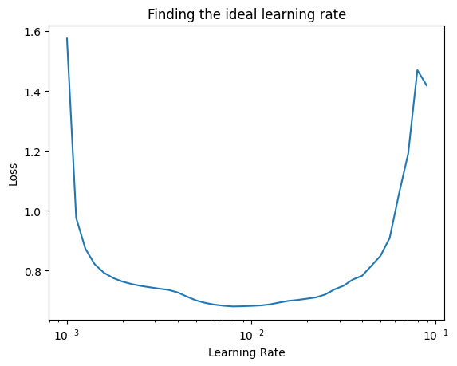

```python
# plot the learning rate decay curve
import numpy as np
import matplotlib.pyplot as plt
lrs = 1e-3 * (10**(np.arange(40)/20)) # recreating learning rate value from model to put in graph
plt.semilogx(lrs, find_lr_history.history['loss']) # want our x-axis to be log-scale
plt.xlabel('Learning Rate')
plt.ylabel('Loss')
plt.title('Finding the ideal learning rate');
```

```python
tf.random.set_seed(42)

model_14=tf.keras.Sequential([
    tf.keras.layers.Flatten(input_shape=(28,28)),
    tf.keras.layers.Dense(4,activation='relu'),
    tf.keras.layers.Dense(4,activation='relu'),
    tf.keras.layers.Dense(10,activation='softmax')
])

model_14.compile(loss=tf.keras.losses.SparseCategoricalCrossentropy(),
                 optimizer=tf.keras.optimizers.Adam(learning_rate=0.001), # add in our custom learning rate
                 metrics=['accuracy'])

history=model_14.fit(train_data,
                     train_labels,
                     epochs=20,
                     validation_data=(test_data,test_labels))
```

```
1875/1875 ━━━━━━━━━━━━━━━━━━━━ 7s 3ms/step - accuracy: 0.3080 - loss: 1.7715 - val_accuracy: 0.6220 - val_loss: 1.0056
1875/1875 ━━━━━━━━━━━━━━━━━━━━ 5s 3ms/step - accuracy: 0.6284 - loss: 0.9536 - val_accuracy: 0.6553 - val_loss: 0.8403
1875/1875 ━━━━━━━━━━━━━━━━━━━━ 6s 3ms/step - accuracy: 0.6704 - loss: 0.8219 - val_accuracy: 0.6810 - val_loss: 0.7925
1875/1875 ━━━━━━━━━━━━━━━━━━━━ 6s 3ms/step - accuracy: 0.6917 - loss: 0.7776 - val_accuracy: 0.7146 - val_loss: 0.7556
1875/1875 ━━━━━━━━━━━━━━━━━━━━ 6s 3ms/step - accuracy: 0.7308 - loss: 0.7347 - val_accuracy: 0.7516 - val_loss: 0.6968
1875/1875 ━━━━━━━━━━━━━━━━━━━━ 6s 3ms/step - accuracy: 0.7590 - loss: 0.6824 - val_accuracy: 0.7621 - val_loss: 0.6715
1875/1875 ━━━━━━━━━━━━━━━━━━━━ 5s 3ms/step - accuracy: 0.7661 - loss: 0.6579 - val_accuracy: 0.7659 - val_loss: 0.6594
1875/1875 ━━━━━━━━━━━━━━━━━━━━ 5s 3ms/step - accuracy: 0.7718 - loss: 0.6438 - val_accuracy: 0.7708 - val_loss: 0.6504
1875/1875 ━━━━━━━━━━━━━━━━━━━━ 5s 3ms/step - accuracy: 0.7759 - loss: 0.6342 - val_accuracy: 0.7736 - val_loss: 0.6444
1875/1875 ━━━━━━━━━━━━━━━━━━━━ 5s 3ms/step - accuracy: 0.7792 - loss: 0.6269 - val_accuracy: 0.7761 - val_loss: 0.6394
1875/1875 ━━━━━━━━━━━━━━━━━━━━ 5s 3ms/step - accuracy: 0.7831 - loss: 0.6210 - val_accuracy: 0.7776 - val_loss: 0.6356
1875/1875 ━━━━━━━━━━━━━━━━━━━━ 6s 3ms/step - accuracy: 0.7855 - loss: 0.6159 - val_accuracy: 0.7809 - val_loss: 0.6329
1875/1875 ━━━━━━━━━━━━━━━━━━━━ 5s 3ms/step - accuracy: 0.7865 - loss: 0.6117 - val_accuracy: 0.7821 - val_loss: 0.6298
1875/1875 ━━━━━━━━━━━━━━━━━━━━ 5s 3ms/step - accuracy: 0.7875 - loss: 0.6082 - val_accuracy: 0.7839 - val_loss: 0.6275
1875/1875 ━━━━━━━━━━━━━━━━━━━━ 5s 3ms/step - accuracy: 0.7887 - loss: 0.6050 - val_accuracy: 0.7853 - val_loss: 0.6259
1875/1875 ━━━━━━━━━━━━━━━━━━━━ 5s 2ms/step - accuracy: 0.7895 - loss: 0.6024 - val_accuracy: 0.7870 - val_loss: 0.6245
1875/1875 ━━━━━━━━━━━━━━━━━━━━ 5s 3ms/step - accuracy: 0.7905 - loss: 0.6000 - val_accuracy: 0.7870 - val_loss: 0.6232
1875/1875 ━━━━━━━━━━━━━━━━━━━━ 5s 3ms/step - accuracy: 0.7917 - loss: 0.5978 - val_accuracy: 0.7871 - val_loss: 0.6223
1875/1875 ━━━━━━━━━━━━━━━━━━━━ 5s 3ms/step - accuracy: 0.7925 - loss: 0.5957 - val_accuracy: 0.7880 - val_loss: 0.6215
1875/1875 ━━━━━━━━━━━━━━━━━━━━ 5s 3ms/step - accuracy: 0.7933 - loss: 0.5938 - val_accuracy: 0.7879 - val_loss: 0.6195
```

We could:

- Evaluate its performance using other classification metrics (such as a `confusion matrix` or `classification report`)
- Assess some of its predictions (through visualizations)
- Improve its accuracy (by training it for longer or changing the architecture)
- Save and export it for use in an application

Let's go through the first two options

First we'll create a classification matrix to visualize its predictions across the different classes.

```python
# creating a confusion matrix code
import itertools
from sklearn.metrics import confusion_matrix

# our function needs a different name to sklearn's plot_confusion_matrix
def make_confusion_matrix(y_true, y_pred, classes=None, figsize=(10,10), text_size=15):
    """Makes a labelled confusion matrix comparing predictions and ground truth labels.

    If classes is passed, confusion matrix will be labelled, if not, interger class values will be used.

    Args:
        y_true: Array of truth labels (must be same shape as y_pred)
        y_pred: Array of predicted labels (must be same shape as y_true)
        classes: Array of class labels (e.g. string form). If 'None', integer labels are used
        figsize: Size of output figure (default=(10,10))
        text_size: Size of output figure test (default=15)

    Returns:
        A labelled confusion matrix plot comparing y_true and y_pred

    Example usage:
        make_confusion_matrix(y_true=test_labes, # ground truth test labels
                              y_pred=y_preds, # predicted labels
                              classes=class_names, # array of class label names
                              figsize=(15,15),
                              text_size=10)
    """
    # create the confusion matrix
    cm = confusion_matrix(y_true, y_pred) # confusion_matrix() computes the true and predicted value, into a matrix/2d grid
    cm_norm = cm.astype('float') / cm.sum(axis=1)[:, np.newaxis] # normalize it, to get the percentage of data residing in a matrix grid, based on total number of true predictions for category '1'. Put this in new axis too
    n_classes = cm.shape[0] # find the number of classes we're dealing with

    # plot the figure and make it pretty
    fig, ax = plt.subplots(figsize=figsize)
    cax = ax.matshow(cm, cmap=plt.cm.Blues) # colors will represent how 'correct' it is. Deeper the colour, the more data is in, in one of the boxes
    fig.colorbar(cax) # add colour bar for better comparison to matrix

    # are there a list of classes?
    if classes:
        labels=classes
    else:
        labels=np.arange(cm.shape[0]) # if no labels, create them numerically based on how many is in the dataset

    # label the axes
    ax.set(title='Confusion Matrix',
           xlabel='Predicted label',
           ylabel='True label',
           xticks=np.arange(n_classes), # create enough axis slots for each class
           yticks=np.arange(n_classes),
           xticklabels=labels, # axes will labeled with class names (if they exist) or ints
           yticklabels=labels)

    # Make x-axis labels appear on bottom
    ax.xaxis.set_label_position('bottom')
    ax.xaxis.tick_bottom()

    # set the threshold for different colors
    threshold = (cm.max() + cm.min()) / 2. # threshold for colouring of text, which is midpoint between min and max

    # plot the text on each cell
    for i, j in itertools.product(range(cm.shape[0]), range(cm.shape[1])): # goes through entire row and column indices for matrix
        plt.text(j, i, f"{cm[i, j]} ({cm_norm[i, j]*100:.1f}%)", # cm[i, j] > the full count of how many times 'i' was predicted as 'j'
                                                                 # cm_norm[i, j] * 100 > normalized values, for percentage of class 'j' being in 'i'
        horizontalalignment='center',
        color='white' if cm[i, j] > threshold else 'black', # white text is used based on threshold that was coded before, else black
        size=text_size)
```

since a confusion matrix compares the truth labels (`test_label`) to the predicted labels, we have to make some predictions with out model.

```python
# Make predictions with the most recent model
y_probs = model_14.predict(test_data)

# view the first 5 predictions
y_probs[:5]
```

```
313/313 ━━━━━━━━━━━━━━━━━━━━ 1s 2ms/step
```

```
array([[7.4860941e-06, 4.2478553e-13, 9.6544767e-08, 8.5035595e-08,
        9.3509138e-11, 3.2663199e-01, 4.7957604e-07, 1.3311964e-01,
        4.2339801e-04, 5.3981680e-01],
       [5.8837165e-04, 7.1241764e-08, 7.8836811e-01, 6.4166272e-07,
        6.9408514e-02, 3.2813263e-09, 1.1423043e-01, 3.0295807e-30,
        2.7403759e-02, 1.5028944e-16],
       [4.7488720e-05, 9.8712385e-01, 2.8926981e-04, 8.5273823e-03,
        3.7407745e-03, 1.3933755e-14, 2.7119598e-04, 4.5449404e-29,
        3.2060539e-09, 1.7519102e-21],
       [4.6427838e-05, 9.8730415e-01, 2.5632273e-04, 8.8728694e-03,
        3.2726056e-03, 1.5464345e-14, 2.4768893e-04, 7.5086171e-29,
        2.9875031e-09, 2.2023464e-21],
       [1.2378435e-01, 7.4998025e-06, 2.2898906e-01, 4.2006541e-03,
        5.6589656e-02, 3.2366272e-09, 5.6916076e-01, 1.4687701e-29,
        1.7268008e-02, 6.7419333e-15]], dtype=float32)
```

Our model outputs prediction probabilities with all possible classes, based on its likeleness on the image the neural network recieves.

Higher the prediction value, the more likely the model believes is the right class.

To find highest value, we use `argmax()` method.

```python
# see the predicted class number and label for the first example
y_probs[0].argmax(), class_names[y_probs[0].argmax()]
```

```
(np.int64(9), 'Ankle boot')
```

Now let's do the same for all of the predictions

```python
# Convert all of the predictions from probabilities to labels
y_preds = y_probs.argmax(axis=1)

# View the first 10 prediction labels
y_preds[:10]
```

```
array([9, 2, 1, 1, 6, 1, 4, 6, 5, 7])
```

Wonderful! Now we've got our model's predictions in label form, let's create a confusion matrix to view them against the truth labels.

```python
# Check out the non-prettified confusion matrix
from sklearn.metrics import confusion_matrix
confusion_matrix(y_true=test_labels,
                 y_pred=y_preds)
```

```
array([[685,   5,  15, 111,   4,  10, 135,   0,  35,   0],
       [  0, 947,  13,  27,   6,   2,   3,   0,   2,   0],
       [ 13,   9, 663,  10, 177,   4, 111,   0,  13,   0],
       [ 44,  18,  14, 813,  35,   8,  65,   0,   3,   0],
       [  1,   7, 183,  20, 717,   0,  70,   0,   2,   0],
       [  0,   0,   1,   1,   0, 882,   0,  54,   3,  59],
       [159,   3, 167,  54, 143,   4, 438,   0,  32,   0],
       [  0,   0,   0,   0,   0,  35,   0, 944,   0,  21],
       [ 13,   2,  18,   4,   3,  30,  20,   5, 905,   0],
       [  0,   0,   0,   0,   0,  36,   0,  76,   3, 885]])
```

The confusion matrix is hard to comprehend, so we'll use the function before that makes it look pretty.

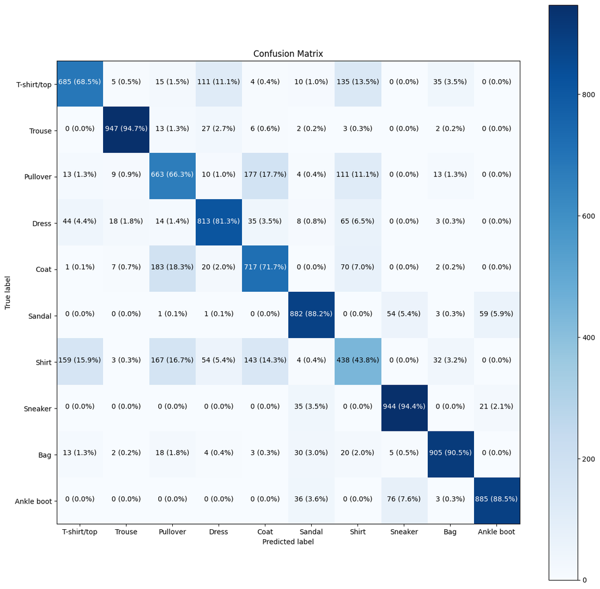

```python
# Make a prettier confusion matrix
make_confusion_matrix(y_true=test_labels,
                      y_pred=y_preds,
                      classes=class_names,
                      figsize=(15,15),
                      text_size=10)
```

Looks much better! But the results aren't as good as they can be.

It seems that our model is having trouble with predicting `Shirts` and `Pullovers`, often mixing up one with the other. We also notice that `Shirts` are often the category to get confused with other categories as well. It kind of makes sense, as `Shirts` are often a very generic shape of a clothing item, and can be easily mistaken with other clothing items that has the general shape as it is.

We see how the model prediction lines up the truth value quite well still in the confusion matrix. But how aboue we visualize some with the actual images with it?

Let's create a function to plot a random image along with its prediction.

> 💡 **Note**: Often when working with images and other visual data, its a good iea to visualize as much as possible to develop a better understanding of the data and the outputs of the model.

```python
import random

# Create a function for plotting a random image along with its prediction
def plot_random_image(model, images, true_labels, classes):
    """
    Picks a random image, plots it and labels it with a predicted and truth label.

    Args:
        model: a trained model (trained on data similar to what's in images).
        images: a set of random images (in tensor form).
        true_labels: array of ground truth labels for images.
        classes: array of class names for images.

    Returns:
        A plot of a random image from 'images' with a predicted class label from 'model' as well as the truth class label from 'true_labels'.
    """

    # Setup random integer
    i = random.randint(0, len(images))

    # Create predictions and targets
    target_image = images[i]
    pred_probs = model.predict(target_image.reshape(1,28,28)) # reshape 28 by 28 to right shape for model
    pred_label = classes[pred_probs.argmax()]
    true_label = classes[true_labels[i]]

    # Plot the target image
    plt.imshow(target_image, cmap=plt.cm.binary)

    # Change the color of the titles depending on if the prediction is right or wrong
    if pred_label == true_label:
        color='green'
    else:
        color='red'

    # Add xlabel information (prediction/true label)
    plt.xlabel("Pred: {} {:2.0f}% (True: {})".format(pred_label, 100*tf.reduce_max(pred_probs), true_label),
               color=color) # set colour from our if else table
```

```
1/1 ━━━━━━━━━━━━━━━━━━━━ 0s 73ms/step
```

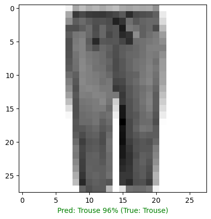

```python
# check out a random image as well as its prediction
plot_random_image(model=model_14,
                  images=test_data,
                  true_labels=test_labels,
                  classes=class_names)
```

After running the cell above a few times, you'll start to get a visual understanding of the relationship between the model's predictions and the true labels.

What predictions does the model get confused by? Usually its `shirt` with any kind of clothing that covers the upper half of the body, with sleeves. It makes them look quite similar to shirts because of the shape! This tells us that the model learn's its patterns, likely by the shape the clothing creates. And when two objects have similar shape, their predictions can get mixed up.

#### What patterns is our model learning?

We've been talking a lot about how a neural network finds patterns in numbers, but what exactly do these patterns look like?

Let's crack open one of our models (`model_14`), and investigate its list of layers. We can look into it using `layers` attribute.

```python
# Find the layers of our most recent model
model_14.layers
```

```
[<Flatten name=flatten_4, built=True>,
 <Dense name=dense_40, built=True>,
 <Dense name=dense_41, built=True>,
 <Dense name=dense_42, built=True>]
```

We can access a target ayer using indexing.

```python
# Extract a particular layer
model_14.layers[1]
```

```
<Dense name=dense_40, built=True>
```

We can find the patterns the model has learnt using the `get_weight()` method. It returns the **weights** (knowns as weights matrix) and **biases** (known as a bias vector) of a particular layer.

```python
# Get the patterns of a layer in our network
weights, biases = model_14.layers[1].get_weights()

# Shape = 1 weight matrix the size of our input data (28x28) per neuron (4)
weights, weights.shape
```

```
(array([[ 0.07796155, -0.89438784,  0.51512474,  0.38815898],
        [-0.06947594, -0.21920316,  0.09221172, -0.17972332],
        [ 0.00797619, -1.0931828 ,  1.0324686 ,  0.35687974],
        ...,
        [-0.03260972, -0.10891435, -0.04386219, -0.460864  ],
        [ 0.07767674, -0.38967183,  0.37427008, -0.6692344 ],
        [-0.03993164, -0.3799016 ,  0.4038273 ,  0.5101351 ]],
       dtype=float32),
 (784, 4))
```

The weights of the matrix, is the same shape as the input data (28x28, which is 784). And there's a copy of the weights matrix for each neuron in the selected layer (our selected layer has 4 neurons).

Each value in the weights matrix corresponds to how a particular value in the input data influences the network's decisions.

These values are all randomly generated (set by the `kernel_initializer` parameter when creating a layer, the default is `glorot_uniform`) which are then updated for better representation of the data by the neural network during training.

[figure not shown]

*Example workflow of how a supervised neural network starts, with using random weight initially, and updating to better represent the data through looking at examples of ideal outputs.*

Noe let's check out the bias vector.

```python
# Shape = 1 bias per neuron (we use 4 neurons in the first laayer)
biases, biases.shape
```

```
(array([-0.01499707,  0.65599084, -0.1622887 ,  1.8565606 ], dtype=float32),
 (4,))
```

Every neuron has a bias vector, and is eah paired with a weight matrix.

The bias values get initialized as zeroes by default (using the `bias_initializer` parameter).

The bias vector dictates how much the patterns within the coresponding weights matrix should influence the next layer.

```python
# Can now calculae the number of parameters in our model
model_14.summary()
```

```
Model: "sequential_15"
```

```
┏━━━━━━━━━━━━━━━━━━━━━━━━━━━━━━━━━┳━━━━━━━━━━━━━━━━━━━━━━━━┳━━━━━━━━━━━━━━━┓
┃ Layer (type)                    ┃ Output Shape           ┃       Param # ┃
┡━━━━━━━━━━━━━━━━━━━━━━━━━━━━━━━━━╇━━━━━━━━━━━━━━━━━━━━━━━━╇━━━━━━━━━━━━━━━┩
│ flatten_4 (Flatten)             │ (None, 784)            │             0 │
├─────────────────────────────────┼────────────────────────┼───────────────┤
│ dense_40 (Dense)                │ (None, 4)              │         3,140 │
├─────────────────────────────────┼────────────────────────┼───────────────┤
│ dense_41 (Dense)                │ (None, 4)              │            20 │
├─────────────────────────────────┼────────────────────────┼───────────────┤
│ dense_42 (Dense)                │ (None, 10)             │            50 │
└─────────────────────────────────┴────────────────────────┴───────────────┘
```

```
 Total params: 9,632 (37.63 KB)
```

```
 Trainable params: 3,210 (12.54 KB)
```

```
 Non-trainable params: 0 (0.00 B)
```

```
 Optimizer params: 6,422 (25.09 KB)
```

After building some deep learning odels, we'll explore the whole concept of inputs and outputs. Not only as it relates to a model as a whole, but every layer within the model.

Starting from the input ayer, each subsequent layer's input is the output of the previous layer. We can see that clearly using the utility `plot_model()`.

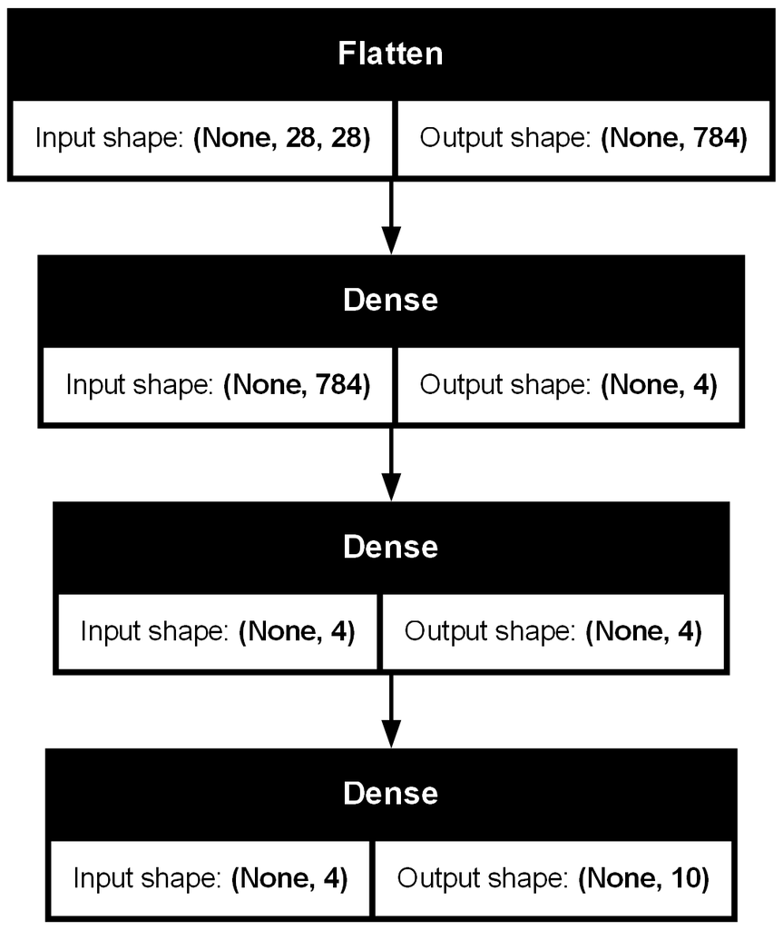

```python
from tensorflow.keras.utils import plot_model

# See the inputs and outputs of each layer
plot_model(model_14, show_shapes=True)
```

### How a model learns (in brief)

We've done a bunch of models, but what really happens under the hood? How does the model exactly learn?

A model learns by updating and improving its weight matrice and bias values of every epoch (in our case, when we call the `fit()` function).

It does so by comparing the patterns its learned between the data and labels to the actual labels.

If the current patterns (weight matrices and bias values) don't result in a desirable decrease in the loss function (higher loss means worse predictions), the optimizer tries to steer the model to update its patterns in the right way, by trying to decrease loss, and using the true labels as reference.

The process of using real labels as reference for improving model predictions is called **backpropagation**.

In other words, data and labels pass through a model (**forward pass**) and it attempts to learn the relationship between the data and labels.

If the learned relationship isn't close to actual relationship, or that it could be inproved, the model goes back through itself (**backward pass**) and tweaking its weight matrices and bias values to better represent the data.

If all this is confusing, there's some extra cirricular content at the bottom of the workbook.

### Exercises

1. Play with neural network in the TensorFlow Playground, try different values and see what it does
2. Replicate the model pictured under this on TensorFlow Playground using TensorFlow code. Compile it with the Adam optimizer, binary crossentropy loss and accuracy metric. Once it's compiled check a summary of the model

[figure not shown]

*Try this network out for yourself on the TensorFlow Playground website as well. Hint: there are 5 hidden layers but the output layer isn't pictured. Decide what the output layer shall be, based on the input data.*

3. Create a classification dataset using Scikit-Learn's [make_moons()](https://scikit-learn.org/stable/modules/generated/sklearn.datasets.make_moons.html) function, visualize it, and then build a model to fit it at over 85% accuracy.
4. Create function to visualize multiple image predictions for the fashin MNIST at the same time. Plot at least three different images and their prediction labels at the sae time. Hint: see the [classification tutorial in the TensorFlow documentation](https://www.tensorflow.org/tutorials/keras/classification) for ideas.
5. Recreate [TensorFlow's softmax activation function](https://en.wikipedia.org/wiki/Softmax_function) in your own code. Make sure it can accept a tensor and return that tensor after having the softmax function applied to it.
6. Train model to get +88% accuracy on the fashion MNIST test set. Plot a confusion matrix to see the results after.
7. Make a fnction to show an image of a certain class of the fashion MNIST dataset and make a prediction on it. For example, plot 3 images of the `T-shirt` class with their predictions.

### Extra curriculum 📖

- Watch 3Blue1Brown's neural networks video 2: *[Gradient descent, how neural networks learn](https://www.youtube.com/watch?v=IHZwWFHWa-w)*. After you're done, write 100 words about what you've learned.
  - If you haven't already, watch video 1: *[But what is a Neural Network?](https://youtu.be/aircAruvnKk)*. Note the activation function they talk about at the end.
- Watch *[MIT's introduction to deep learning lecture 1](https://youtu.be/njKP3FqW3Sk)* (if you haven't already) to get an idea of the concepts behind using linear and non-linear functions.
- Spend 1-hour reading [Michael Nielsen's Neural Networks and Deep Learning book](http://neuralnetworksanddeeplearning.com/index.html).
- Read the [ML-Glossary documentation on activation functions](https://ml-cheatsheet.readthedocs.io/en/latest/activation_functions.html). Which one is your favourite?
  - After you've read the ML-Glossary, see which activation functions are available in TensorFlow by searching "tensorflow activation functions".

```python
pip install nbconvert PyPDF2
```

[output not shown]